# Data Camp Insights

Example code includes:

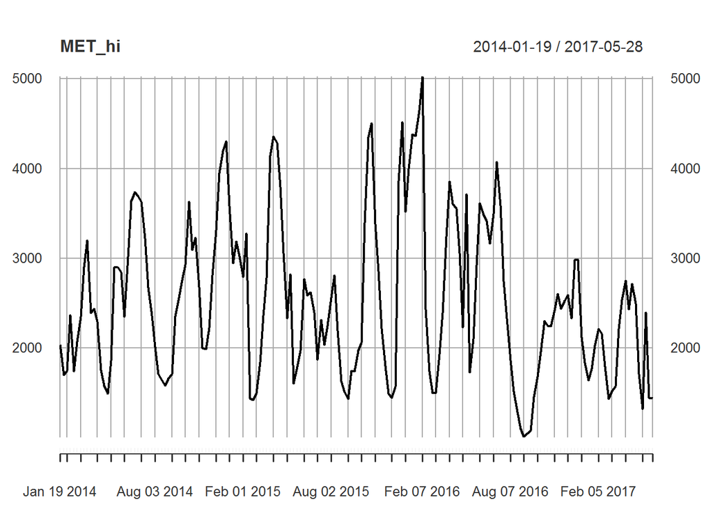

```r
bev_xts_train <- bev_xts[index(bev_xts) < "2017-01-01"]
bev_xts_valid <- bev_xts[index(bev_xts) >= "2017-01-01"]

# Save the prices of each product
l_MET_hi_p <- log(as.vector(bev_xts_train[, "MET.hi.p"]))

# Save as a data frame
MET_hi_train <- data.frame(as.vector(log(MET_hi[index(MET_hi) < "2017-01-01"])), l_MET_hi_p)
colnames(MET_hi_train) <- c("log_sales", "log_price")

# Calculate the regression
model_MET_hi <- lm(log_sales ~ log_price, data = MET_hi_train)


# Plot the product's sales
plot(MET_hi)
```

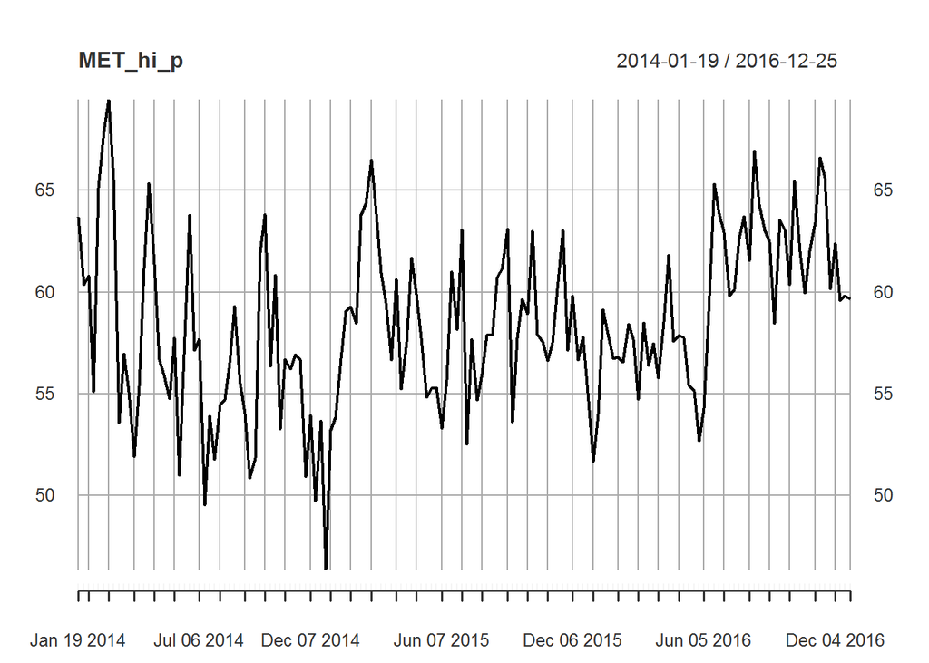

```r
# Plot the product's price
MET_hi_p <- bev_xts_train[, "MET.hi.p"]
plot(MET_hi_p)
```

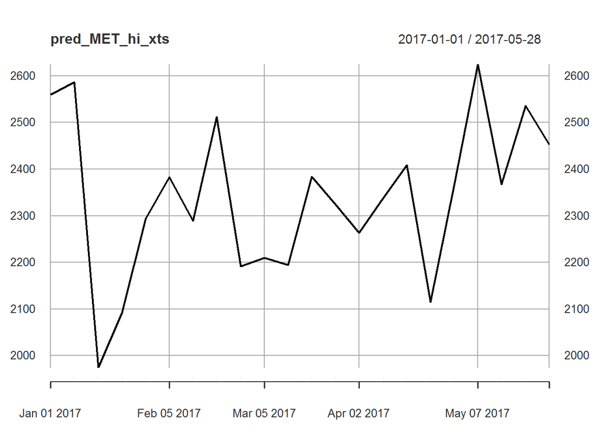

```r
# Create date indices for New Year's week
n.dates <- as.Date(c("2014-12-28", "2015-12-27", "2016-12-25"))

# Create xts objects for New Year's
newyear <- as.xts(rep(1, 3), order.by = n.dates)

# Create sequence of dates for merging
dates_train <- seq(as.Date("2014-01-19"), length = 154, by = "weeks")

# Merge training dates into New Year's object
newyear <- merge(newyear, dates_train, fill = 0)


# Add newyear variable to your data frame
MET_hi_train <- data.frame(MET_hi_train, newyear=as.vector(newyear))

# Build regressions for the product
model_MET_hi_full <- lm(log_sales ~ log_price + newyear, data = MET_hi_train)


# Subset the validation prices #
l_MET_hi_p_valid <- log(as.vector(bev_xts_valid[, "MET.hi.p"]))

# Create a validation data frame #
MET_hi_valid <- data.frame(l_MET_hi_p_valid)
colnames(MET_hi_valid) <- "log_price"


# Predict the log of sales for your high end product
pred_MET_hi <- predict(model_MET_hi, MET_hi_valid)

# Convert predictions out of log scale
pred_MET_hi <- exp(pred_MET_hi)


# Convert to an xts object
dates_valid <- seq(as.Date("2017-01-01"), length = 22, by = "weeks")
pred_MET_hi_xts <- xts(pred_MET_hi, order.by = dates_valid)

# Plot the forecast
plot(pred_MET_hi_xts)
```

```r
# Calculate and print the MAPE
MET_hi_v <- bev_xts_valid[,"MET.hi"]

MAPE <- 100*mean(abs((pred_MET_hi_xts - MET_hi_v)/MET_hi_v))
print(MAPE)
```

```
## [1] 29.57455
```

Chapter 3 - Blending Regression with Time Series

Residuals from regression model:

- The residuals from the regression models can be used for further modeling - see if the residuals are related over time, and model them with time series if so
- Need to start by gathering the residuals and then converting them to an XTS object - explore for patterns in this XTS object

Forecasting residuals:

- When the residuals are related across time, we can use time series to model the residuals - basically, patterns to the errors provide an opportunity for further modeling
- Can use auto.arima() on the residuals data, to see what the best ARIMA model for the residuals is
  - Can then forecast the residuals in to the future using forecast(myModel, h=) # h being the time periods to predict forward

Transfer functions and ensembling:

- Techniques for combining forecasts - single model (transfer function) or averaging of models (ensembling)
- Demand can be based on both regression (modeling external factors) and time series (residuals)
- Ensembling is a combination (blend) of the forecasts, with simple averaging being the simplest approach
  - Basically, build a stand-alone time series model and a stand-alone regression model
  - The ensemble forecast can be better or worse than any of the stand-alone models

Example code includes:

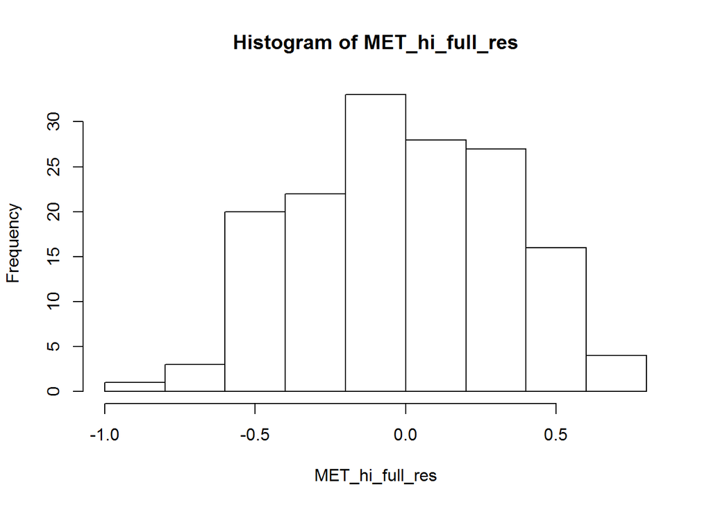

```r
# Calculate the residuals from the model
MET_hi_full_res <- resid(model_MET_hi_full)

# Convert the residuals to an xts object
MET_hi_full_res <- xts(MET_hi_full_res, order.by = dates_train)


# Plot the histogram of the residuals
hist(MET_hi_full_res)
```

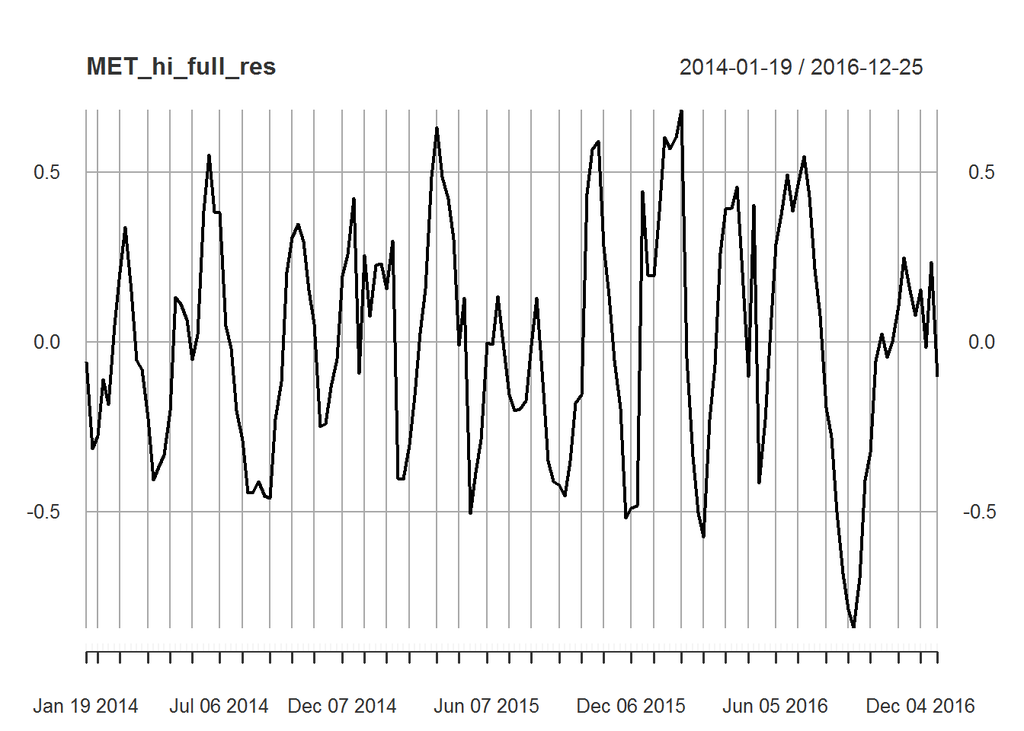

```r
# Plot the residuals over time
plot(MET_hi_full_res)
```

```r
# Build an ARIMA model on the residuals: MET_hi_arima
MET_hi_arima <- auto.arima(MET_hi_full_res)

# Look at a summary of the model
summary(MET_hi_arima)
```

```
## Series: MET_hi_full_res
## ARIMA(2,0,2) with zero mean
##
## Coefficients:
##          ar1      ar2      ma1     ma2
##       1.5736  -0.7833  -0.8149  0.2865
## s.e.  0.0992   0.0758   0.1266  0.0941
##
## sigma^2 estimated as 0.03921:  log likelihood=32.19
## AIC=-54.37   AICc=-53.97   BIC=-39.19
##
## Training set error measures:
##                         ME      RMSE      MAE       MPE     MAPE      MASE
## Training set -0.0004334041 0.1954382 0.145018 -47.18396 223.0022 0.5227844
##                     ACF1
## Training set -0.01034041
```

```r
# Forecast 22 weeks with your model: for_MET_hi_arima
for_MET_hi_arima <- forecast(MET_hi_arima, h=22)

# Print first 10 observations
head(for_MET_hi_arima$mean, n = 10)
```

```
## Time Series:
## Start = 1079
## End = 1142
## Frequency = 0.142857142857143
##  [1] -0.07662326 -0.10617141 -0.10705342 -0.08529747 -0.05037188
##  [6] -0.01245420  0.01985656  0.04100076  0.04896519  0.04493645
```

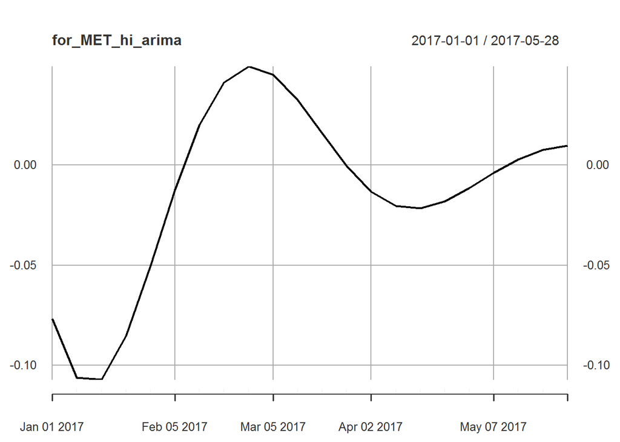

```r
# Convert your forecasts into an xts object
dates_valid <- seq(as.Date("2017-01-01"), length = 22, by = "weeks")
for_MET_hi_arima <- xts(for_MET_hi_arima$mean, order.by = dates_valid)

# Plot the forecast
plot(for_MET_hi_arima)
```

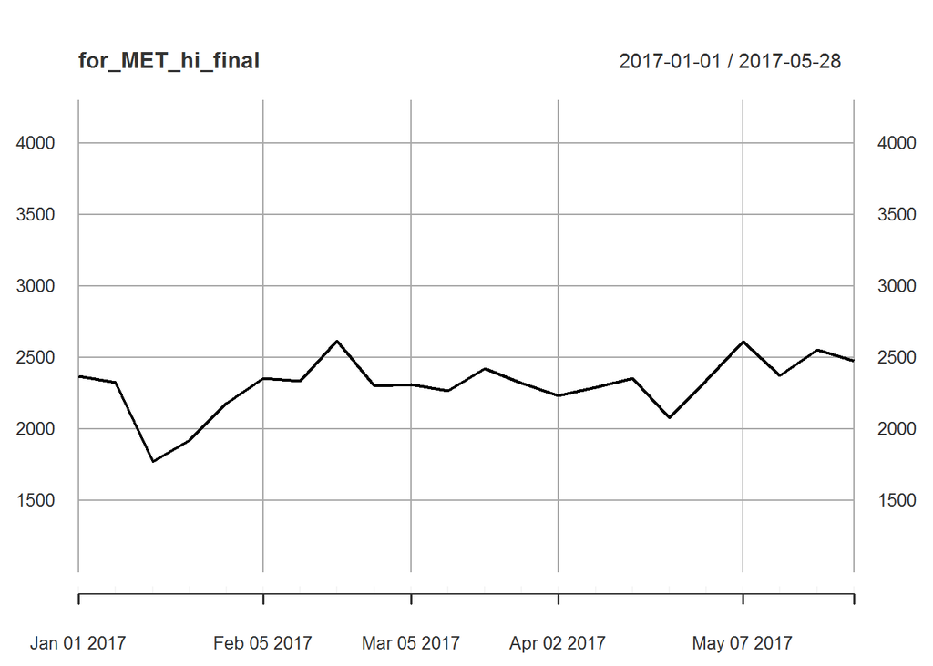

```r
# Convert your residual forecast to the exponential version
for_MET_hi_arima <- exp(for_MET_hi_arima)

# Multiply your forecasts together!
for_MET_hi_final <- for_MET_hi_arima * pred_MET_hi_xts


# Plot the final forecast - don't touch the options!
plot(for_MET_hi_final, ylim = c(1000, 4300))
```

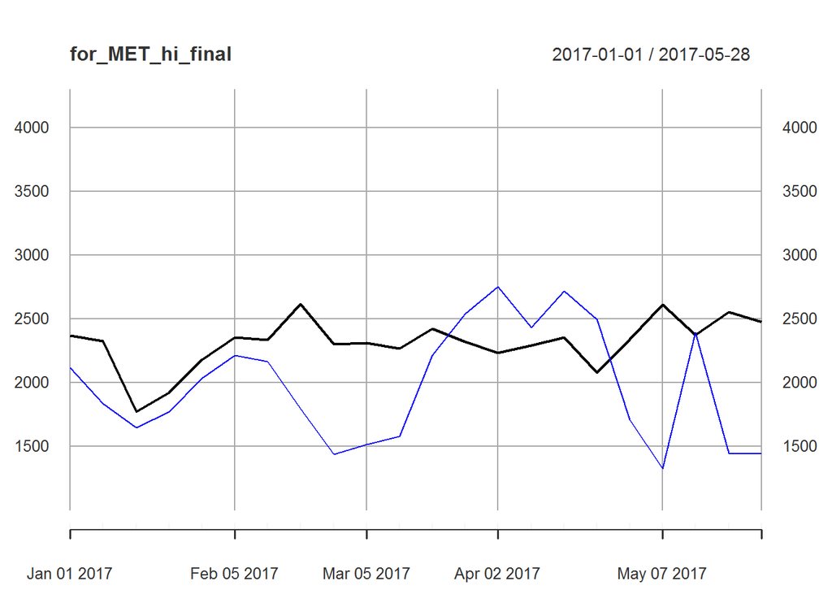

```r
# Overlay the validation data set
lines(MET_hi_v, col = "blue")
```

```r
# Calculate the MAE
MAE <- mean(abs(for_MET_hi_final - MET_hi_v))
print(MAE)
```

```
## [1] 481.6678
```

```r
# Calculate the MAPE
MAPE <- 100 * mean(abs(for_MET_hi_final - MET_hi_v)/MET_hi_v)
print(MAPE)
```

```
## [1] 28.82836
```

```r
# Build an ARIMA model using the auto.arima function
MET_hi_model_arima <- auto.arima(MET_hi)

# Forecast the ARIMA model
for_MET_hi <- forecast(MET_hi_model_arima, h = length(MET_hi_v))

# Save the forecast as an xts object
dates_valid <- seq(as.Date("2017-01-01"), length = 22, by = "weeks")
for_MET_hi_xts <- xts(for_MET_hi$mean, order.by = dates_valid)

# Calculate the MAPE of the forecast
MAPE <- 100 * mean(abs(for_MET_hi_xts - MET_hi_v) / MET_hi_v)
print(MAPE)
```

```
## [1] 36.95411
```

```r
# Ensemble the two forecasts together
for_MET_hi_en <- 0.5 * (for_MET_hi_xts + pred_MET_hi_xts)

# Calculate the MAE and MAPE
MAE <- mean(abs(for_MET_hi_en - MET_hi_v))
print(MAE)
```

```
## [1] 533.8911
```

```r
MAPE <- 100 * mean(abs(for_MET_hi_en - MET_hi_v) / MET_hi_v)
print(MAPE)
```

```
## [1] 32.28549
```

Chapter 4 - Hierarchical Forecasting

Bottom-Up Hierarchical Forecasting:

- The hierarchical data structuring can be an advantage in forecasting, provided that the data has a natural hierarchy
- The sum of all the lower-level forecasts should equal the higher-level forecasts
  - Bottom-up: Forecast at the lowest level and aggregate (easiest but requires the most number of forecasts)
  - Top-down: Forecast at the top level and the apply downwards
  - Middle-out: Forecast at the middle levels and then apply both upwards and downwards

Top-Down Hierarchical Forecasting:

- The top-down forecasting process is typically quicker but less accurate than the bottom-up forecasting process
- Two techniques available for top-down reconciliation
  - Average of historical proportions - mean percentage that each component contributes to the total (calculated by sub-component such as week)
  - Proportion of historical averages - mean percentage that each component contributes to the total (calculated by aggregate)
- Reconciled forecasts at lower levels are typically less accurate than the direct forecast of the lower levels

Middle-Out Hierarchical Forecasting:

- Bottom-up forecasting is higher quality but more time-consuming than top-down forecasting
- The middle-out forecasting method is a sometimes successful blend of the methods, getting decent accuracy at a lesser time commitment

Wrap up:

- Using time series to forecast demand forward
- Incorporating external factors using linear regression
- Blending time series and regression approaches
- Top-down, bottom-up, middle-out approaches to aggregation and forecasting at various levels (hierarchical)
- Can extend by looking at cross-elasticities (impact of competitor pricing)
- Can better forecast proportions using time series analysis
- Additional demand forecasting models include neural networks, exponential smoothing, etc.

Example code includes:

```r
# Build a time series model
MET_sp_model_arima <- auto.arima(MET_sp)

# Forecast the time series model for 22 periods
for_MET_sp <- forecast(MET_sp_model_arima, h=22)

# Create an xts object
for_MET_sp_xts <- xts(for_MET_sp$mean, order.by=dates_valid)

MET_sp_v <- MET_sp["2017"]

# Calculate the MAPE
MAPE <- 100 * mean(abs(for_MET_sp_xts - MET_sp_v) / MET_sp_v)
print(MAPE)
```

```
## [1] 6.703272
```

```r
MET_sp_train <- bev_xts_train %>%
    transform(log_sales = log(MET.sp), log_price=log(MET.sp.p))
MET_sp_train <- MET_sp_train[, c("log_sales", "log_price")]
MET_sp_train$newyear <- 0
MET_sp_train$valentine <- 0
MET_sp_train$christmas <- 0
MET_sp_train$mother <- 0

MET_sp_train[index(MET_sp_train) %in% as.Date(c("2014-12-28", "2015-12-27", "2016-12-25")), "newyear"] <- 1
MET_sp_train[index(MET_sp_train) %in% as.Date(c("2014-02-09", "2015-02-08", "2016-02-07")), "valentine"] <- 1
MET_sp_train[index(MET_sp_train) %in% as.Date(c("2014-12-21", "2015-12-20", "2016-12-18")), "christmas"] <- 1
MET_sp_train[index(MET_sp_train) %in% as.Date(c("2014-05-04", "2015-05-03", "2016-05-01")), "mother"] <- 1


# THE BELOW IS TOTAL NONSENSE
# Build a regression model
model_MET_sp <- lm(log_sales ~ log_price + newyear + valentine + christmas + mother, data = MET_sp_train)


MET_sp_valid <- as.data.frame(bev_xts_valid) %>%
    mutate(log_sales = log(MET.sp), log_price=log(MET.sp.p)) %>%
    select("log_sales", "log_price")
MET_sp_valid$newyear <- 0
MET_sp_valid$valentine <- 0
MET_sp_valid$christmas <- 0
MET_sp_valid$mother <- 0

MET_sp_valid[7, "valentine"] <- 1
MET_sp_valid[19, "mother"] <- 1
MET_sp_valid$log_sales <- NULL


# Forecast the regression model using the predict function
pred_MET_sp <- predict(model_MET_sp, MET_sp_valid)

# Exponentiate your predictions and create an xts object
pred_MET_sp <- exp(pred_MET_sp)
pred_MET_sp_xts <- xts(pred_MET_sp, order.by = dates_valid)

# Calculate MAPE
MAPE <- 100*mean(abs((pred_MET_sp_xts - MET_sp_v)/MET_sp_v))
print(MAPE)
```

```
## [1] 6.55473
```

```r
# Ensemble the two forecasts
for_MET_sp_en <- 0.5 * (for_MET_sp_xts + pred_MET_sp_xts)

# Calculate the MAPE
MAPE <- 100 * mean(abs(for_MET_sp_en - MET_sp_v) / MET_sp_v)
print(MAPE)
```

```
## [1] 6.048594
```

```r
# Copy over pred_MET_lo_xts
pred_MET_lo_xts <- xts(c(2960.6, 2974.1, 2943.2, 2948.6, 2915.6, 2736.4, 2953.9, 3199.4, 2934, 2898.7, 3027.7, 3165.9, 3073.1, 2842.7, 2928.7, 3070.2, 2982.2, 3018, 3031.9, 2879.4, 2993.2, 2974.1), order.by=dates_valid)


# Calculate the metropolitan regional sales forecast
for_MET_total <- pred_MET_hi_xts + for_MET_sp_en + pred_MET_lo_xts

# Calculate a validation data set
MET_t_v <- bev_xts_valid[,"MET.hi"] + bev_xts_valid[,"MET.lo"] + bev_xts_valid[,"MET.sp"]

# Calculate the MAPE
MAPE <- 100 * mean(abs(for_MET_total - MET_t_v) / MET_t_v)
print(MAPE)
```

```
## [1] 10.61952
```

```r
# Create the MET_total data
MET_total <- xts(data.frame(MET.hi=c(5942, 5600, 5541, 6892, 5586, 5943, 6329, 6693, 6938, 6138, 6361, 6378, 5423, 5097, 4937, 5496, 6870, 6626, 6356, 5657, 6577, 7202, 7381, 7404, 7204, 6667, 6153, 6035, 5633, 5283, 5178, 4758, 5058, 5254, 5954, 6166, 6247, 6304, 7202, 6662, 6814, 6174, 5412, 5380, 5674, 6472, 6912, 7404, 8614, 8849, 7174, 6489, 7174, 6555, 6402, 7671, 5012, 4790, 5075, 5238, 5615, 6113, 7706, 7811, 7898, 7232, 6585, 5870, 7084, 5125, 5330, 5553, 6349, 6195, 6271, 5851, 5333, 5854, 5609, 5649, 6051, 6409, 5786, 5190, 5085, 4949, 5151, 5147, 5426, 5509, 6956, 7870, 8224, 6685, 6153, 5802, 5244, 5162, 5036, 5025, 8378, 8944, 7109, 7605, 7846, 7598, 8012, 9551, 6102, 5366, 4932, 4962, 5392, 6194, 7239, 7621, 7460, 7097, 6596, 5848, 8306, 5344, 5848, 6341, 7364, 7269, 7053, 6682, 6971, 7521, 7063, 6298, 6003, 5227, 5047, 4877, 4851, 4628, 4516, 4442, 4935, 5181, 5431, 5866, 5919, 5704, 5957, 6019, 5962, 6021, 5880, 5674, 7439, 7415)),
                 order.by=dates_train
                 )

# Build a regional time series model
MET_t_model_arima <- auto.arima(MET_total)

# Calculate a 2017 forecast for 22 periods
for_MET_t <- forecast(MET_t_model_arima, h=22)

# Make an xts object from your forecast
for_MET_t_xts <- xts(for_MET_t$mean, order.by=dates_valid)

# Calculate the MAPE
MAPE <- 100 * mean(abs(for_MET_t_xts - MET_t_v) / MET_t_v)
print(MAPE)
```

```
## [1] 17.10332
```

```r
# Calculate the average historical proportions
prop_hi <- mean(MET_hi/MET_total)
prop_lo <- mean(MET_lo/MET_total)
prop_sp <- mean(MET_sp/MET_total)

# Distribute out your forecast to each product
for_prop_hi <- prop_hi*for_MET_t_xts
for_prop_lo <- prop_lo*for_MET_t_xts
for_prop_sp <- prop_sp*for_MET_t_xts

# Calculate the MAPE's for each product
MAPE_hi <- 100 * mean(abs(for_prop_hi - MET_hi_v) / MET_hi_v)
print(MAPE_hi)
```

```
## [1] 38.7318
```

```r
MET_lo_v <- bev_xts_valid[,"MET.lo"]
MAPE_lo <- 100 * mean(abs(for_prop_lo - MET_lo_v) / MET_lo_v)
print(MAPE_lo)
```

```
## [1] 10.70649
```

```r
MAPE_sp <- 100 * mean(abs(for_prop_sp - MET_sp_v) / MET_sp_v)
print(MAPE_sp)
```

```
## [1] 6.232888
```

```r
# Calculate the average historical proportions
prop_hi_2 <- mean(MET_hi) / mean(MET_total)
prop_lo_2 <- mean(MET_lo) / mean(MET_total)
prop_sp_2 <- mean(MET_sp) / mean(MET_total)

# Distribute out your forecast to each product
for_prop_hi_2 <- prop_hi_2 * for_MET_t_xts
for_prop_lo_2 <- prop_lo_2 * for_MET_t_xts
for_prop_sp_2 <- prop_sp_2 * for_MET_t_xts

# Calculate the MAPE's for each product
MAPE_hi <- 100 * mean(abs(for_prop_hi_2 - MET_hi_v) / MET_hi_v)
print(MAPE_hi)
```

```
## [1] 38.33559
```

```r
MAPE_lo <- 100 * mean(abs(for_prop_lo_2 - MET_lo_v) / MET_lo_v)
print(MAPE_lo)
```

```
## [1] 8.450784
```

```r
MAPE_sp <- 100 * mean(abs(for_prop_sp_2 - MET_sp_v) / MET_sp_v)
print(MAPE_sp)
```

```
## [1] 6.517045
```

```r
SEC_total <- xts(data.frame(SEC.hi=c(700, 775, 789, 863, 765, 759, 757, 747, 746, 709, 749, 786, 796, 726, 727, 723, 778, 755, 739, 740, 723, 695, 727, 707, 725, 684, 667, 698, 727, 722, 748, 695, 742, 739, 715, 724, 686, 671, 688, 682, 710, 700, 672, 680, 695, 780, 751, 693, 809, 881, 703, 712, 768, 796, 808, 904, 641, 662, 693, 725, 719, 736, 715, 722, 732, 745, 689, 705, 811, 739, 744, 700, 745, 735, 732, 722, 721, 732, 750, 714, 752, 677, 731, 674, 720, 675, 741, 722, 715, 719, 649, 697, 743, 733, 772, 698, 690, 734, 713, 644, 788, 833, 749, 731, 670, 675, 675, 993, 773, 751, 697, 677, 750, 723, 780, 763, 721, 701, 704, 684, 985, 791, 731, 714, 704, 694, 685, 652, 708, 754, 747, 705, 711, 699, 712, 745, 706, 665, 666, 692, 676, 696, 689, 697, 689, 717, 697, 708, 660, 707, 715, 680, 922, 888)), order.by=dates_train
                 )

# Build a time series model for the region
SEC_t_model_arima <- auto.arima(SEC_total)

# Forecast the time series model
for_SEC_t <- forecast(SEC_t_model_arima, h=22)

# Make into an xts object
for_SEC_t_xts <- xts(for_SEC_t$mean, order.by=dates_valid)

SEC_t_v <- bev_xts_valid$SEC.hi + bev_xts_valid$SEC.lo
# Calculate the MAPE
MAPE <- 100 * mean(abs(for_SEC_t_xts - SEC_t_v) / SEC_t_v)
print(MAPE)
```

```
## [1] 4.742324
```

```r
SEC_hi <- bev_xts_train[, "SEC.hi"]
SEC_lo <- bev_xts_train[, "SEC.lo"]
SEC_hi_v <- bev_xts_valid[, "SEC.hi"]
SEC_lo_v <- bev_xts_valid[, "SEC.lo"]

# Calculate the average of historical proportions
prop_hi <- mean(SEC_hi / SEC_total)
prop_lo <- mean(SEC_lo / SEC_total)

# Distribute the forecast
for_prop_hi <- prop_hi * for_SEC_t_xts
for_prop_lo <- prop_lo * for_SEC_t_xts

# Calculate a MAPE for each product
MAPE_hi <- 100 * mean(abs(for_prop_hi - SEC_hi_v) / SEC_hi_v)
print(MAPE_hi)
```

```
## [1] 7.988508
```

```r
MAPE_lo <- 100 * mean(abs(for_prop_lo - SEC_lo_v) / SEC_lo_v)
print(MAPE_lo)
```

```
## [1] 5.202529
```

```r
# Copy over for_M_t_xts data
for_M_t_xts <- xts(c(2207, 2021, 2010, 2052, 2075, 2074, 2065, 2058, 2056, 2055, 2053, 2052, 2050, 2049, 2048, 2047, 2046, 2045, 2044, 2043, 2043, 2042), order.by=dates_valid)

# Calculate the state sales forecast: for_state
for_state = for_SEC_t_xts + for_MET_t_xts + for_M_t_xts

# See the forecasts
for_state
```

```
##                [,1]
## 2017-01-01 9996.689
## 2017-01-08 9525.915
## 2017-01-15 9342.760
## 2017-01-22 9269.321
## 2017-01-29 9214.912
## 2017-02-05 9162.005
## 2017-02-12 9118.199
## 2017-02-19 9087.859
## 2017-02-26 9070.209
## 2017-03-05 9058.715
## 2017-03-12 9049.677
## 2017-03-19 9043.959
## 2017-03-26 9038.794
## 2017-04-02 9035.673
## 2017-04-09 9033.250
## 2017-04-16 9031.296
## 2017-04-23 9029.656
## 2017-04-30 9028.227
## 2017-05-07 9026.939
## 2017-05-14 9025.746
## 2017-05-21 9025.617
## 2017-05-28 9024.530
```

### *HR Analytics in R: Exploring Employee Data*

Chapter 1 - Identifying the Best Recruiting Source

Introduction - Ben Teusch, HR Analytics Consultant:

- HR analytics has many other names - people analytics, workforce analytics, etc.
- Identify groups for comparison - high vs. low performers, groups with high vs. low turnover, etc.
  - Exploratory analysis and statistics for each group, including plots of key differences
- Course is outlines as a series of case studies, with one case per chapter

Recruiting and quality of hire:

- Where are the best hires coming from, and how can you get more of them
  - Defining quality of hire is challenging - some mix of productivity, satisfaction, retention, performance reviews, etc.
  - Attrition can be defined as the mean of a 1, 0 vector of “did the person leave in the time period T”

Visualizing recruiting data:

- Helpful for communicating findings to decision makers
- The geom_col() in ggplot will make a bar chart, with the y aestehtic being the bar height

Example code includes:

```r
# Import the recruitment data
recruitment <- readr::read_csv("./RInputFiles/recruitment_data.csv")
# Look at the first few rows of the dataset
head(recruitment)
```

```
## # A tibble: 6 x 4
##   attrition performance_rating sales_quota_pct recruiting_source
##       <int>              <int>           <dbl> <chr>
## 1         1                  3           1.09  Applied Online
## 2         0                  3           2.39  <NA>
## 3         1                  2           0.498 Campus
## 4         0                  2           2.51  <NA>
## 5         0                  3           1.42  Applied Online
## 6         1                  3           0.548 Referral
```

```r
# Get an overview of the recruitment data
summary(recruitment)
```

```
##    attrition     performance_rating sales_quota_pct   recruiting_source
##  Min.   :0.000   Min.   :1.000      Min.   :-0.7108   Length:446
##  1st Qu.:0.000   1st Qu.:2.000      1st Qu.: 0.5844   Class :character
##  Median :0.000   Median :3.000      Median : 1.0701   Mode  :character
##  Mean   :0.213   Mean   :2.895      Mean   : 1.0826
##  3rd Qu.:0.000   3rd Qu.:3.000      3rd Qu.: 1.5325
##  Max.   :1.000   Max.   :5.000      Max.   : 3.6667
```

```r
# See which recruiting sources the company has been using
recruitment %>%
  count(recruiting_source)
```

```
## # A tibble: 5 x 2
##   recruiting_source     n
##   <chr>             <int>
## 1 Applied Online      130
## 2 Campus               56
## 3 Referral             45
## 4 Search Firm          10
## 5 <NA>                205
```

```r
# Find the average sales quota attainment for each recruiting source
avg_sales <- recruitment %>%
  group_by(recruiting_source) %>%
  summarize(avg_sales_quota_pct=mean(sales_quota_pct))

# Display the result
avg_sales
```

```
## # A tibble: 5 x 2
##   recruiting_source avg_sales_quota_pct
##   <chr>                           <dbl>
## 1 Applied Online                  1.06
## 2 Campus                          0.908
## 3 Referral                        1.02
## 4 Search Firm                     0.887
## 5 <NA>                            1.17
```

```r
# Find the average attrition for the sales team, by recruiting source, sorted from lowest attrition rate to highest
avg_attrition <- recruitment %>%
  group_by(recruiting_source) %>%
  summarize(attrition_rate=mean(attrition)) %>%
  arrange(attrition_rate)

# Display the result
avg_attrition
```

```
## # A tibble: 5 x 2
##   recruiting_source attrition_rate
##   <chr>                      <dbl>
## 1 <NA>                       0.132
## 2 Applied Online             0.246
## 3 Campus                     0.286
## 4 Referral                   0.333
## 5 Search Firm                0.500
```

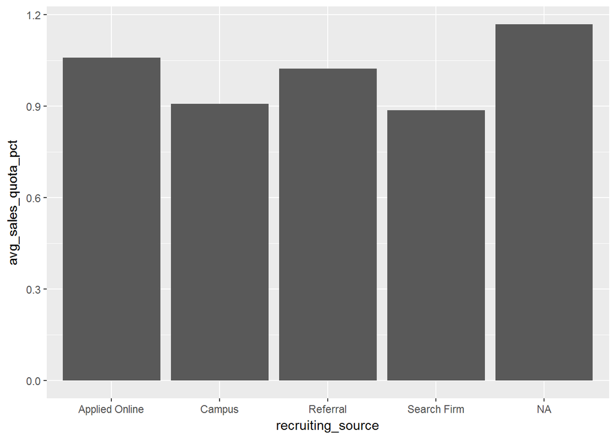

```r
# Plot the bar chart
avg_sales %>% ggplot(aes(x=recruiting_source, y=avg_sales_quota_pct)) + geom_col()
```

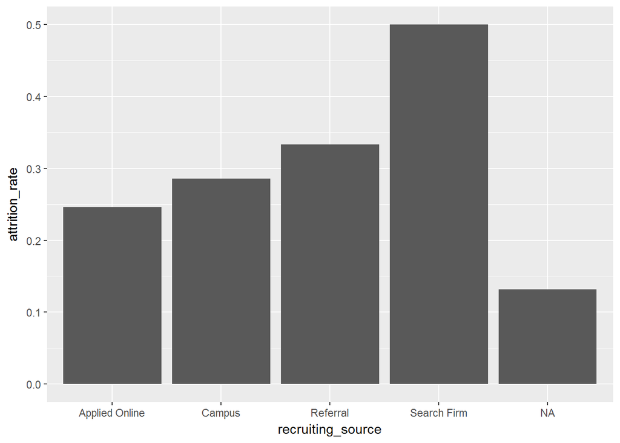

```r
# Plot the bar chart
avg_attrition %>% ggplot(aes(x=recruiting_source, y=attrition_rate)) + geom_col()
```

Chapter 2 - What is driving low employee engagement

Analyzing employee engagement:

- Gallup defines engaged employees as those who are involved in, enthusiastic about, and committed to their workplace
- Survey data are available in the example case study
  - Will use both mutate() and ifelse()
  - The ifelse() is needed for vectors of length > 1 since it can work in a vectorized manner (and is thus OK inside the mutate call)

Visualizing the engagement data:

- Multiple attributes in a single place can make for a more compelling report
- The tidyr package is part of the tidyverse, and hslps arrange the data properly for plotting
  - tidyr::gather(columns, key=“key”, value=“value”) will be the package used in this example - pull the data from the columns down to the rows
  - ggplot(survey_gathered, aes(x = key, y = value, fill = department)) + geom_col(position = “dodge”)
  - ggplot(survey_gathered, aes(x = key, y = value, fill = department)) + geom_col(position = “dodge”) + facet_wrap(~ key, scales = “free”)

Are differences meaningful?

- Can use significance testing to assess likelhood (p-value) that the second sample could have come from the same population as the first sample
  - This course will use t-test (continuous variables) and chi-squared test (categorical variables)
  - t.test(tenure ~ is_manager, data = survey)
  - chisq.test(survey$left_company, survey$is_manager) # no data= argument is available in the function

Example code includes:

```r
# Import the data
survey <- readr::read_csv("./RInputFiles/survey_data.csv")
# Get an overview of the data
summary(survey)
```

```
##   employee_id      department          engagement       salary
##  Min.   :   1.0   Length:1470        Min.   :1.00   Min.   : 45530
##  1st Qu.: 491.2   Class :character   1st Qu.:3.00   1st Qu.: 59407
##  Median :1020.5   Mode  :character   Median :3.00   Median : 70481
##  Mean   :1024.9                      Mean   :3.05   Mean   : 74162
##  3rd Qu.:1555.8                      3rd Qu.:4.00   3rd Qu.: 84763
##  Max.   :2068.0                      Max.   :5.00   Max.   :164073
##  vacation_days_taken
##  Min.   : 0.00
##  1st Qu.: 6.00
##  Median :10.00
##  Mean   :11.27
##  3rd Qu.:16.00
##  Max.   :38.00
```

```r
# Examine the counts of the department variable
survey %>% count(department)
```

```
## # A tibble: 3 x 2
##   department      n
##   <chr>       <int>
## 1 Engineering   961
## 2 Finance        63
## 3 Sales         446
```

```r
# Output the average engagement score for each department, sorted
survey %>%
  group_by(department) %>%
  summarize(avg_engagement=mean(engagement)) %>%
  arrange(avg_engagement)
```

```
## # A tibble: 3 x 2
##   department  avg_engagement
##   <chr>                <dbl>
## 1 Sales                 2.81
## 2 Engineering           3.15
## 3 Finance               3.24
```

```r
# Create the disengaged variable and assign the result to survey
survey_disengaged <- survey %>%
  mutate(disengaged = ifelse(engagement <= 2, 1, 0))

survey_disengaged
```

```
## # A tibble: 1,470 x 6
##    employee_id department  engagement salary vacation_days_tak~ disengaged
##          <int> <chr>            <int>  <dbl>              <int>      <dbl>
##  1           1 Sales                3 103264                  7       0
##  2           2 Engineering          3  80709                 12       0
##  3           4 Engineering          3  60737                 12       0
##  4           5 Engineering          3  99116                  7       0
##  5           7 Engineering          3  51022                 18       0
##  6           8 Engineering          3  98400                  9       0
##  7          10 Engineering          3  57106                 18       0
##  8          11 Engineering          1  55065                  4       1.00
##  9          12 Engineering          4  77158                 12       0
## 10          13 Engineering          2  48365                 14       1.00
## # ... with 1,460 more rows
```

```r
# Summarize the three variables by department
survey_summary <- survey_disengaged %>%
  group_by(department) %>%
  summarize(pct_disengaged=mean(disengaged),
            avg_salary=mean(salary),
            avg_vacation_taken=mean(vacation_days_taken)
            )

survey_summary
```

```
## # A tibble: 3 x 4
##   department  pct_disengaged avg_salary avg_vacation_taken
##   <chr>                <dbl>      <dbl>              <dbl>
## 1 Engineering          0.206      73576              12.2
## 2 Finance              0.190      76652              11.5
## 3 Sales                0.330      75074               9.22
```

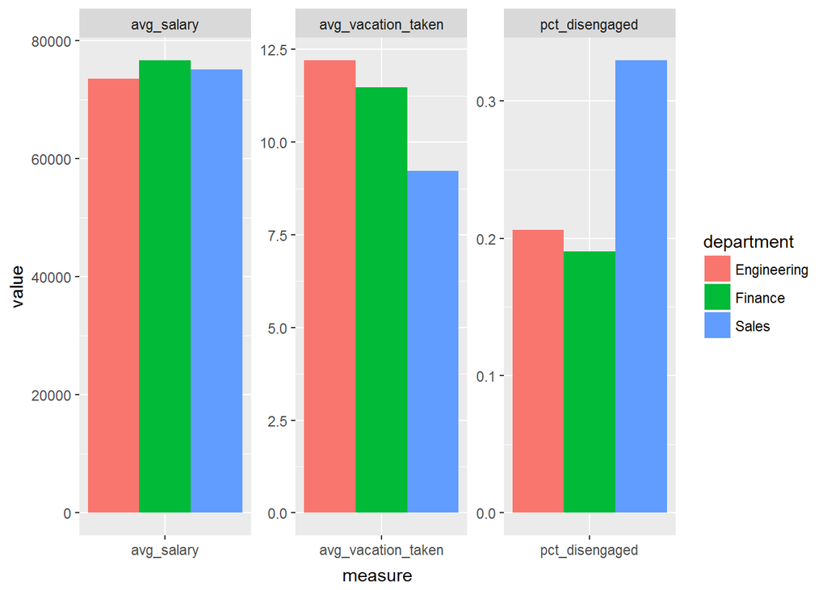

```r
# Gather data for plotting
survey_gathered <- survey_summary %>%
  gather(key = "measure", value = "value",
         pct_disengaged, avg_salary, avg_vacation_taken)

# Create three bar charts
ggplot(survey_gathered, aes(x=measure, y=value, fill=department)) +
  geom_col(position="dodge") +
  facet_wrap(~ measure, scales="free")
```

```r
# Add the in_sales variable
survey_sales <- survey %>%
  mutate(in_sales = ifelse(department == "Sales", "Sales", "Other"),
         disengaged = ifelse(engagement < 3, 1L, 0L)
         )

# Test the hypothesis using survey_sales
chisq.test(survey_sales$disengaged, survey_sales$in_sales)
```

```
##
##  Pearson's Chi-squared test with Yates' continuity correction
##
## data:  survey_sales$disengaged and survey_sales$in_sales
## X-squared = 25.524, df = 1, p-value = 4.368e-07
```

```r
t.test(disengaged ~ in_sales, data=survey_sales)
```

```
##
##  Welch Two Sample t-test
##
## data:  disengaged by in_sales
## t = -4.862, df = 743.16, p-value = 1.419e-06
## alternative hypothesis: true difference in means is not equal to 0
## 95 percent confidence interval:
##  -0.17479596 -0.07424062
## sample estimates:
## mean in group Other mean in group Sales
##           0.2050781           0.3295964
```

```r
# Test the hypothesis using the survey_sales data
t.test(vacation_days_taken ~ in_sales, data = survey_sales)
```

```
##
##  Welch Two Sample t-test
##
## data:  vacation_days_taken by in_sales
## t = 8.1549, df = 1022.9, p-value = 1.016e-15
## alternative hypothesis: true difference in means is not equal to 0
## 95 percent confidence interval:
##  2.229473 3.642409
## sample estimates:
## mean in group Other mean in group Sales
##           12.160156            9.224215
```

Chapter 3 - Are new hires getting paid too much?

Paying new hires fairly:

- Sometimes, current employees get paid less than new employees, which can drive low engagement and turnover
- Case study will have a simulated pay dataset available for analysis
- Can use broom::tidy() to return the outputs in a nicely formatted data frame
  - chisq.test(survey$in_sales, survey$disengaged) %>% tidy()

Omitted variable bias:

- Key assumption of the tests is that the groups are the same, with the exception of the variables being tested
- Omitted variable bias occurs when both 1) the omitted variable is correlated with the dependent variable, and 2) the omitted variable is correlated with an explanatory variable
  - Omitted variables are often known as confounders
  - Plotting can help to identify the issue, particularly with a stacked (to 100%) bar chart
  - pay %>% ggplot(aes(x = new_hire, fill = department)) + geom_bar(position = “fill”)
  - The geom_bar() object has height that is fully dependent on x, in contrast to geom_col() which has a y-aestehtic

Linear regression helps to test the multivariate impacts of variables:

- lm(salary ~ new_hire, data = pay) %>% tidy() # single dependent variable
- lm(salary ~ new_hire + department, data = pay) %>% tidy() # multiple dependent variables
- lm(salary ~ new_hire + department, data = pay) %>% summary() # more detailed summary of the linear regression

Example code includes:

```r
# Import the data
pay <- readr::read_csv("./RInputFiles/fair_pay_data.csv")
# Get an overview of the data
summary(pay)
```

```
##   employee_id      department            salary         new_hire
##  Min.   :   1.0   Length:1470        Min.   : 43820   Length:1470
##  1st Qu.: 491.2   Class :character   1st Qu.: 59378   Class :character
##  Median :1020.5   Mode  :character   Median : 70425   Mode  :character
##  Mean   :1024.9                      Mean   : 74142
##  3rd Qu.:1555.8                      3rd Qu.: 84809
##  Max.   :2068.0                      Max.   :164073
##   job_level
##  Length:1470
##  Class :character
##  Mode  :character
##
##
##
```

```r
# Check average salary of new hires and non-new hires
pay %>%
  group_by(new_hire) %>%
  summarize(avg_salary=mean(salary))
```

```
## # A tibble: 2 x 2
##   new_hire avg_salary
##   <chr>         <dbl>
## 1 No            73425
## 2 Yes           76074
```

```r
# Perform the correct statistical test
t.test(salary ~ new_hire, data = pay)
```

```
##
##  Welch Two Sample t-test
##
## data:  salary by new_hire
## t = -2.3437, df = 685.16, p-value = 0.01938
## alternative hypothesis: true difference in means is not equal to 0
## 95 percent confidence interval:
##  -4869.4242  -429.9199
## sample estimates:
##  mean in group No mean in group Yes
##          73424.60          76074.28
```

```r
t.test(salary ~ new_hire, data = pay) %>%
  broom::tidy()
```

```
##    estimate estimate1 estimate2 statistic    p.value parameter  conf.low
## 1 -2649.672   73424.6  76074.28 -2.343708 0.01937799  685.1554 -4869.424
##   conf.high                  method alternative
## 1 -429.9199 Welch Two Sample t-test   two.sided
```

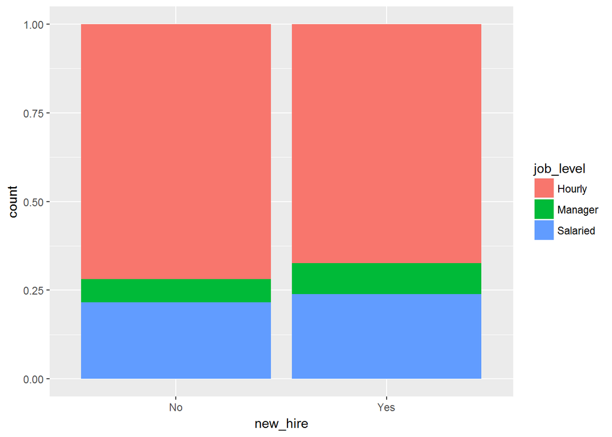

```r
# Create a stacked bar chart
pay %>%
  ggplot(aes(x=new_hire, fill=job_level)) +
  geom_bar(position="fill")
```

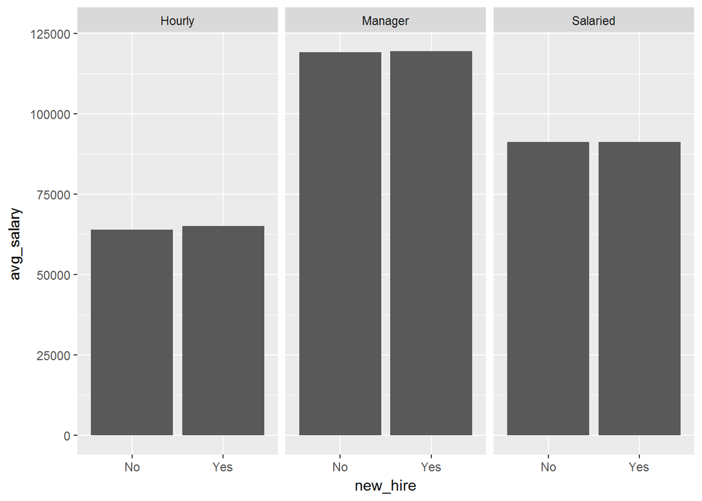

```r
# Calculate the average salary for each group of interest
pay_grouped <- pay %>%
  group_by(new_hire, job_level) %>%
  summarize(avg_salary = mean(salary))

# Graph the results using facet_wrap()
pay_grouped %>%
  ggplot(aes(x=new_hire, y=avg_salary)) +
  geom_col() +
  facet_wrap(~ job_level)
```

```r
# Filter the data to include only hourly employees
pay_filter <- pay %>%
  filter(job_level == "Hourly")

# Test the difference in pay
t.test(salary ~ new_hire, data=pay_filter) %>%
  broom::tidy()
```

```
##    estimate estimate1 estimate2 statistic    p.value parameter  conf.low
## 1 -1106.967  63965.71  65072.68 -1.750387 0.08066517  499.7005 -2349.483
##   conf.high                  method alternative
## 1  135.5483 Welch Two Sample t-test   two.sided
```

```r
# Run the simple regression
model_simple <- lm(salary ~ new_hire, data = pay)

# Display the summary of model_simple
model_simple %>%
  summary()
```

```
##
## Call:
## lm(formula = salary ~ new_hire, data = pay)
##
## Residuals:
##    Min     1Q Median     3Q    Max
## -32255 -14466  -3681  10740  87998
##
## Coefficients:
##             Estimate Std. Error t value Pr(>|t|)
## (Intercept)  73424.6      577.2 127.200   <2e-16 ***
## new_hireYes   2649.7     1109.4   2.388    0.017 *
## ---
## Signif. codes:  0 '***' 0.001 '**' 0.01 '*' 0.05 '.' 0.1 ' ' 1
##
## Residual standard error: 18900 on 1468 degrees of freedom
## Multiple R-squared:  0.003871,   Adjusted R-squared:  0.003193
## F-statistic: 5.705 on 1 and 1468 DF,  p-value: 0.01704
```

```r
# Display a tidy summary
model_simple %>%
  broom::tidy()
```

```
##          term  estimate std.error  statistic    p.value
## 1 (Intercept) 73424.603  577.2369 127.200112 0.00000000
## 2 new_hireYes  2649.672 1109.3568   2.388476 0.01704414
```

```r
# Run the multiple regression
model_multiple <- lm(salary ~ new_hire + job_level, data = pay)

# Display the summary of model_multiple
model_multiple %>%
  summary()
```

```
##
## Call:
## lm(formula = salary ~ new_hire + job_level, data = pay)
##
## Residuals:
##    Min     1Q Median     3Q    Max
## -21013  -7091   -425   6771  44322
##
## Coefficients:
##                   Estimate Std. Error t value Pr(>|t|)
## (Intercept)        64049.3      308.3 207.722   <2e-16 ***
## new_hireYes          782.7      524.8   1.491    0.136
## job_levelManager   54918.8      915.3  60.001   <2e-16 ***
## job_levelSalaried  26865.6      567.2  47.369   <2e-16 ***
## ---
## Signif. codes:  0 '***' 0.001 '**' 0.01 '*' 0.05 '.' 0.1 ' ' 1
##
## Residual standard error: 8930 on 1466 degrees of freedom
## Multiple R-squared:  0.7779, Adjusted R-squared:  0.7775
## F-statistic:  1712 on 3 and 1466 DF,  p-value: < 2.2e-16
```

```r
# Display a tidy summary
model_multiple %>%
  broom::tidy()
```

```
##                term   estimate std.error  statistic       p.value
## 1       (Intercept) 64049.3417  308.3415 207.722067  0.000000e+00
## 2       new_hireYes   782.7358  524.8133   1.491456  1.360570e-01
## 3  job_levelManager 54918.8477  915.2966  60.001152  0.000000e+00
## 4 job_levelSalaried 26865.6336  567.1569  47.368962 7.387196e-298
```

Chapter 4 - Are performance ratings being given consistently?

Joining HR data:

- Employee data tend to be stored in different locations, requiring joins (merges) prior to running analyses
  - dplyr::left_join(hr_data, bonus_pay_data, by = “employee_id”)
  - All employees in hr_data will be kept, even if there is no matching record in bonus_pay_data
  - Employee ID (or similar) is by far the best way to join data - names tend to be non-unique and can differ in different systems

Performance ratings and fairness:

- Performance ratings are inherently subjective and thus prone to bias
- Unconscious bias is based on the brain’s heuristics, and may include preferences for members of various groups (biases, as reflected in hiring, promotion, etc.)

Logistic regression is especially helpful for modeling binary response variables:

- glm(high_performer ~ salary, data = hr, family = “binomial”) %>% tidy()
- glm(high_performer ~ salary + department, data = hr, family = “binomial”) %>% tidy()

Example code includes:

```r
# Import the data
hr_data <- readr::read_csv("./RInputFiles/hr_data.csv")
performance_data <- readr::read_csv("./RInputFiles/performance_data.csv")
# Examine the datasets
summary(hr_data)
```

```
##   employee_id      department         job_level            gender
##  Min.   :   1.0   Length:1470        Length:1470        Length:1470
##  1st Qu.: 491.2   Class :character   Class :character   Class :character
##  Median :1020.5   Mode  :character   Mode  :character   Mode  :character
##  Mean   :1024.9
##  3rd Qu.:1555.8
##  Max.   :2068.0
```

```r
summary(performance_data)
```

```
##   employee_id         rating
##  Min.   :   1.0   Min.   :1.00
##  1st Qu.: 491.2   1st Qu.:2.00
##  Median :1020.5   Median :3.00
##  Mean   :1024.9   Mean   :2.83
##  3rd Qu.:1555.8   3rd Qu.:4.00
##  Max.   :2068.0   Max.   :5.00
```

```r
# Join the two tables
joined_data <- left_join(hr_data, performance_data, by = "employee_id")

# Examine the result
summary(joined_data)
```

```
##   employee_id      department         job_level            gender
##  Min.   :   1.0   Length:1470        Length:1470        Length:1470
##  1st Qu.: 491.2   Class :character   Class :character   Class :character
##  Median :1020.5   Mode  :character   Mode  :character   Mode  :character
##  Mean   :1024.9
##  3rd Qu.:1555.8
##  Max.   :2068.0
##      rating
##  Min.   :1.00
##  1st Qu.:2.00
##  Median :3.00
##  Mean   :2.83
##  3rd Qu.:4.00
##  Max.   :5.00
```

```r
# Check whether the average performance rating differs by gender
joined_data %>%
  group_by(gender) %>%
  summarize(avg_rating = mean(rating))
```

```
## # A tibble: 2 x 2
##   gender avg_rating
##   <chr>       <dbl>
## 1 Female       2.75
## 2 Male         2.92
```

```r
# Add the high_performer column
performance <- joined_data %>%
  mutate(high_performer = ifelse(rating >= 4, 1, 0))

# Test whether one gender is more likely to be a high performer
chisq.test(performance$gender, performance$high_performer)
```

```
##
##  Pearson's Chi-squared test with Yates' continuity correction
##
## data:  performance$gender and performance$high_performer
## X-squared = 22.229, df = 1, p-value = 2.42e-06
```

```r
# Do the same test, and tidy the output
chisq.test(performance$gender, performance$high_performer) %>% broom::tidy()
```

```
##   statistic      p.value parameter
## 1  22.22915 2.419716e-06         1
##                                                         method
## 1 Pearson's Chi-squared test with Yates' continuity correction
```

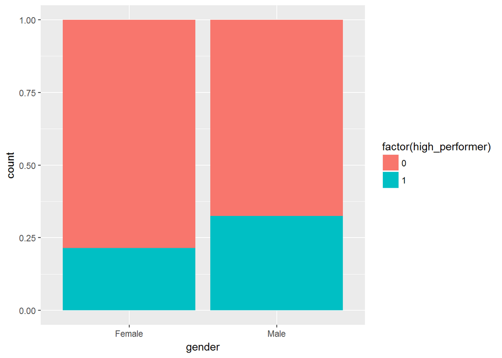

```r
# Visualize the distribution of high_performer by gender
performance %>%
  ggplot(aes(x=gender, fill=factor(high_performer))) +
  geom_bar(position="fill")
```

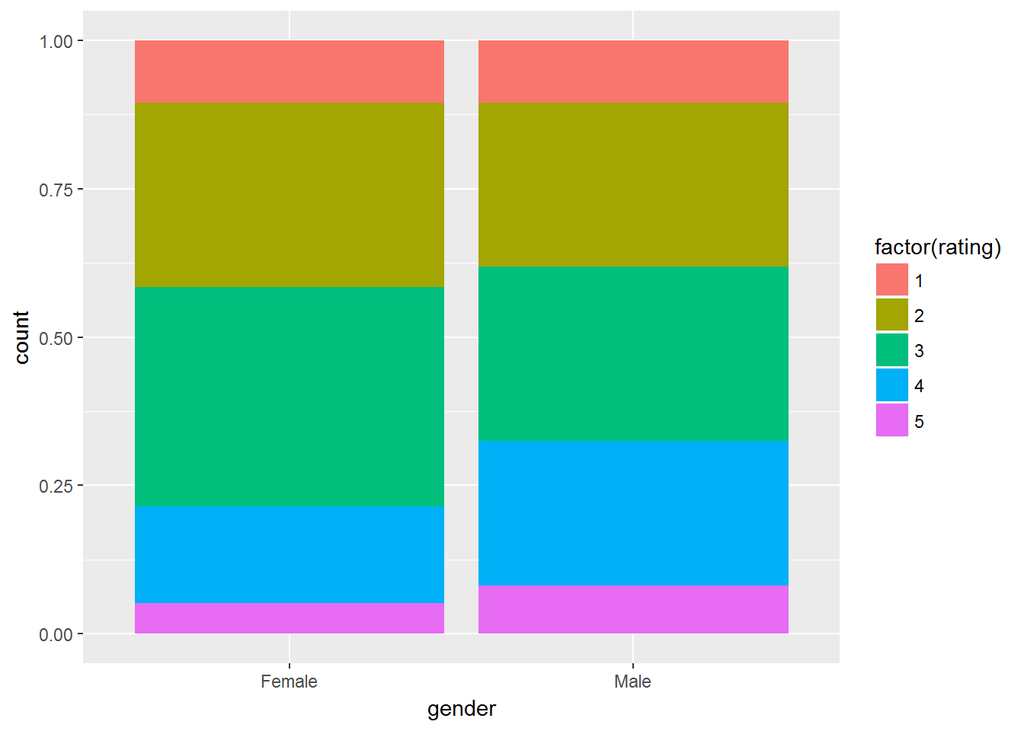

```r
# Visualize the distribution of all ratings by gender
performance %>%
  ggplot(aes(x=gender, fill=factor(rating))) +
  geom_bar(position="fill")
```

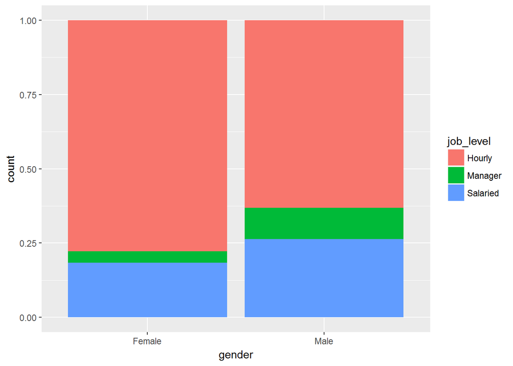

```r
# Visualize the distribution of job_level by gender
performance %>%
  ggplot(aes(x = gender, fill = job_level)) +
  geom_bar(position = "fill")
```

```r
# Test whether men and women have different job level distributions
chisq.test(performance$gender, performance$job_level)
```

```
##
##  Pearson's Chi-squared test
##
## data:  performance$gender and performance$job_level
## X-squared = 44.506, df = 2, p-value = 2.166e-10
```

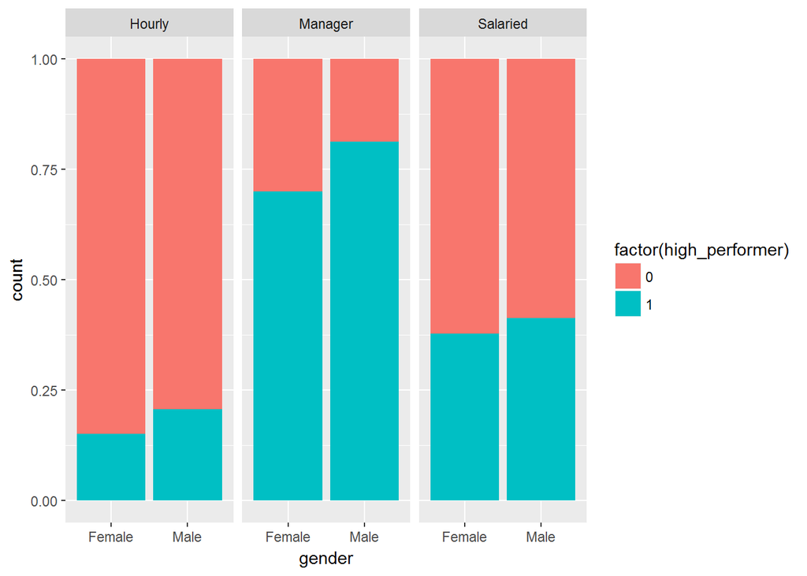

```r
# Visualize the distribution of high_performer by gender, faceted by job level
performance %>%
  ggplot(aes(x = gender, fill = factor(high_performer))) +
  geom_bar(position = "fill") +
  facet_wrap(~ job_level)
```

```r
# Run a simple logistic regression
logistic_simple <- glm(high_performer ~ gender, family = "binomial", data = performance)

# View the result with summary()
logistic_simple %>%
  summary()
```

```
##
## Call:
## glm(formula = high_performer ~ gender, family = "binomial", data = performance)
##
## Deviance Residuals:
##     Min       1Q   Median       3Q      Max
## -0.8871  -0.8871  -0.6957   1.4986   1.7535
##
## Coefficients:
##             Estimate Std. Error z value Pr(>|z|)
## (Intercept) -1.29540    0.08813 -14.699  < 2e-16 ***
## genderMale   0.56596    0.11921   4.748 2.06e-06 ***
## ---
## Signif. codes:  0 '***' 0.001 '**' 0.01 '*' 0.05 '.' 0.1 ' ' 1
##
## (Dispersion parameter for binomial family taken to be 1)
##
##     Null deviance: 1709.0  on 1469  degrees of freedom
## Residual deviance: 1686.1  on 1468  degrees of freedom
## AIC: 1690.1
##
## Number of Fisher Scoring iterations: 4
```

```r
# View a tidy version of the result
logistic_simple %>%
  broom::tidy()
```

```
##          term  estimate std.error  statistic      p.value
## 1 (Intercept) -1.295395 0.0881306 -14.698586 6.581976e-49
## 2  genderMale  0.565958 0.1192110   4.747532 2.059140e-06
```

```r
# Run a multiple logistic regression
logistic_multiple <- glm(high_performer ~ gender + job_level, family = "binomial", data = performance)

# View the result with summary() or tidy()
logistic_multiple %>% broom::tidy()
```

```
##                term   estimate std.error  statistic      p.value
## 1       (Intercept) -1.6945360 0.1025902 -16.517522 2.744425e-61
## 2        genderMale  0.3191103 0.1290197   2.473345 1.338548e-02
## 3  job_levelManager  2.7436430 0.2514410  10.911677 1.013683e-27
## 4 job_levelSalaried  1.0992751 0.1405230   7.822742 5.168508e-15
```

Chapter 5 - Improving employee safety with data

Employee safety - looking at accident rates and drivers:

- Requires joining data on multiple variables
  - joined_data <- left_join(hr_data, safety_data, by = c(“year”, “employee_id”))
  - joined_data %>% filter(is.na(accident_time)) # use is.na() instead

Focusing on the location of interest:

- May want to run comparisons of the same location over time
- May want to assess differences by locations to see if they may be explanatory variables

Explaining the increase in accidents:

- Can use multiple regression to help test for explanatory variables that impact the accident rate

Wrap up:

- Key tools from the Tidyverse (ggplot2, broom, dplyr, etc.) to assess HR data
- Analytics usage within HR, including differences in HR and other data
- Can apply additional data science techniques on HR data

Example code includes:

```r
# Import the data
hr_data <- readr::read_csv("./RInputFiles/hr_data_2.csv")
accident_data <- readr::read_csv("./RInputFiles/accident_data.csv")
# Create hr_joined with left_join() and mutate()
hr_joined <- left_join(hr_data, accident_data, by=c("year", "employee_id")) %>%
  mutate(had_accident=ifelse(is.na(accident_type), 0, 1))

hr_joined
```

```
## # A tibble: 2,940 x 6
##     year employee_id location    overtime_hours accident_type had_accident
##    <int>       <int> <chr>                <int> <chr>                <dbl>
##  1  2016           1 Northwood               14 <NA>                  0
##  2  2017           1 Northwood                8 Mild                  1.00
##  3  2016           2 East Valley              8 <NA>                  0
##  4  2017           2 East Valley             11 <NA>                  0
##  5  2016           4 East Valley              4 <NA>                  0
##  6  2017           4 East Valley              2 Mild                  1.00
##  7  2016           5 West River               0 <NA>                  0
##  8  2017           5 West River              17 <NA>                  0
##  9  2016           7 West River              21 <NA>                  0
## 10  2017           7 West River               9 <NA>                  0
## # ... with 2,930 more rows
```

```r
# Find accident rate for each year
hr_joined %>%
  group_by(year) %>%
  summarize(accident_rate = mean(had_accident))
```

```
## # A tibble: 2 x 2
##    year accident_rate
##   <int>         <dbl>
## 1  2016        0.0850
## 2  2017        0.120
```

```r
# Test difference in accident rate between years
chisq.test(hr_joined$year, hr_joined$had_accident)
```

```
##
##  Pearson's Chi-squared test with Yates' continuity correction
##
## data:  hr_joined$year and hr_joined$had_accident
## X-squared = 9.5986, df = 1, p-value = 0.001947
```

```r
# Which location had the highest acccident rate?
hr_joined %>%
  group_by(location) %>%
  summarize(accident_rate=mean(had_accident)) %>%
  arrange(-accident_rate)
```

```
## # A tibble: 4 x 2
##   location    accident_rate
##   <chr>               <dbl>
## 1 East Valley        0.128
## 2 Southfield         0.103
## 3 West River         0.0961
## 4 Northwood          0.0831
```

```r
# Compare annual accident rates by location
accident_rates <- hr_joined %>%
  group_by(location, year) %>%
  summarize(accident_rate = mean(had_accident))

accident_rates
```

```
## # A tibble: 8 x 3
## # Groups:   location [?]
##   location     year accident_rate
##   <chr>       <int>         <dbl>
## 1 East Valley  2016        0.113
## 2 East Valley  2017        0.143
## 3 Northwood    2016        0.0644
## 4 Northwood    2017        0.102
## 5 Southfield   2016        0.0764
## 6 Southfield   2017        0.130
## 7 West River   2016        0.0824
## 8 West River   2017        0.110
```

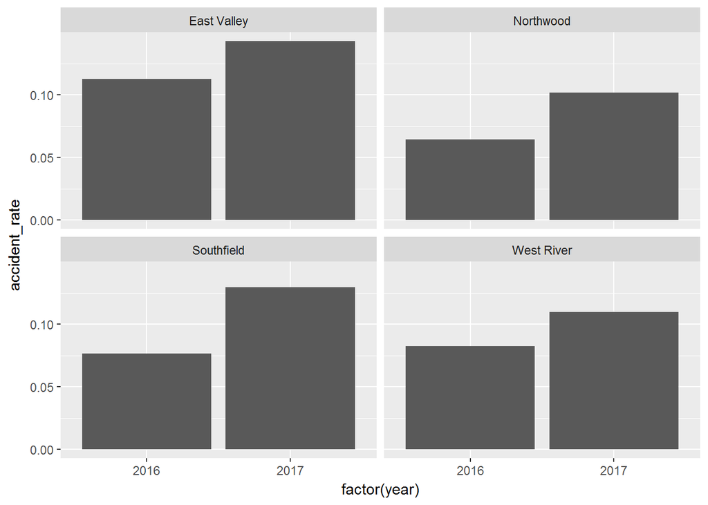

```r
# Graph it
accident_rates %>%
  ggplot(aes(factor(year), accident_rate)) +
  geom_col() +
  facet_wrap(~location)
```

```r
# Filter out the other locations
southfield <- hr_joined %>%
  filter(location == "Southfield")

# Find the average overtime hours worked by year
southfield %>%
  group_by(year) %>%
  summarize(average_overtime_hours = mean(overtime_hours))
```

```
## # A tibble: 2 x 2
##    year average_overtime_hours
##   <int>                  <dbl>
## 1  2016                   8.67
## 2  2017                   9.97
```

```r
# Test difference in Southfield's overtime hours between years
t.test(overtime_hours ~ year, data=southfield)
```

```
##
##  Welch Two Sample t-test
##
## data:  overtime_hours by year
## t = -1.6043, df = 595.46, p-value = 0.1092
## alternative hypothesis: true difference in means is not equal to 0
## 95 percent confidence interval:
##  -2.904043  0.292747
## sample estimates:
## mean in group 2016 mean in group 2017
##           8.667774           9.973422
```

```r
# Import the survey data
survey_data <- readr::read_csv("./RInputFiles/survey_data_2.csv")
```

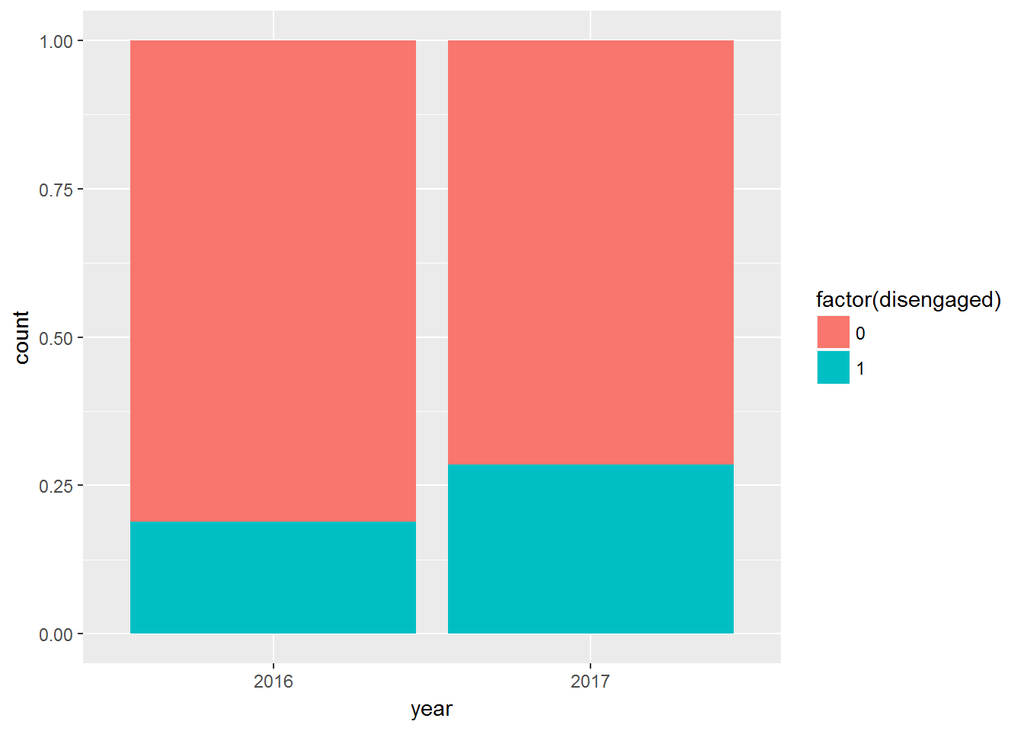

```r
# Create the safety dataset
safety <- left_join(hr_joined, survey_data, by=c("employee_id", "year")) %>%
  mutate(disengaged=ifelse(engagement <= 2, 1, 0), year=factor(year))


# Visualize the difference in % disengaged by year in Southfield
safety %>%
    filter(location=="Southfield") %>%
    ggplot(aes(x = year, fill = factor(disengaged))) +
    geom_bar(position = "fill")
```

```r
# Test whether one year had significantly more disengaged employees
southSafety <- safety %>%
    filter(location=="Southfield")
chisq.test(southSafety$disengaged, southSafety$year)
```

```
##
##  Pearson's Chi-squared test with Yates' continuity correction
##
## data:  southSafety$disengaged and southSafety$year
## X-squared = 7.1906, df = 1, p-value = 0.007329
```

```r
# Filter out Southfield
other_locs <- safety %>%
  filter(location != "Southfield")

# Test whether one year had significantly more overtime hours worked
t.test(overtime_hours ~ year, data = other_locs)
```

```
##
##  Welch Two Sample t-test
##
## data:  overtime_hours by year
## t = -0.48267, df = 2320.3, p-value = 0.6294
## alternative hypothesis: true difference in means is not equal to 0
## 95 percent confidence interval:
##  -0.9961022  0.6026035
## sample estimates:
## mean in group 2016 mean in group 2017
##           9.278015           9.474765
```

```r
# Test whether one year had significantly more disengaged employees
chisq.test(other_locs$year, other_locs$disengaged)
```

```
##
##  Pearson's Chi-squared test with Yates' continuity correction
##
## data:  other_locs$year and other_locs$disengaged
## X-squared = 0.0023091, df = 1, p-value = 0.9617
```

```r
# Use multiple regression to test the impact of year and disengaged on accident rate in Southfield
regression <- glm(had_accident ~ year + disengaged, family = "binomial", data = southSafety)

# Examine the output
regression %>% broom::tidy()
```

```
##          term   estimate std.error  statistic      p.value
## 1 (Intercept) -2.9237983 0.2504685 -11.673318 1.744826e-31
## 2    year2017  0.4402062 0.2848346   1.545480 1.222302e-01
## 3  disengaged  1.4425408 0.2780927   5.187265 2.134047e-07
```

### *Supervised Learning in R: Case Studies*

Chapter 1 - Cars Data

Making predictions using machine learning:

- Course focuses on applied skills from predictive learning, using regression and classification as well as EDA
  - Regression tends to be for predicting continuous, numeric variables
  - Classification tends to be for predicting categorical variables
- Case studies include 1) fuel efficiency, 2) Stack Overflow developer survey, 3) voter turnout, and 4) ages of nuns
- The fuel efficiency data is stored in cars2018 and is based on data from the US Department of Energy
  - Variables names with spaces can be handled by surrounding them with backticks
  - Tidyverse includes tibble, readr, ggplot2, dplyr, tidyr, purrr, etc. - can be loaded as a package using library(tidyverse)

Getting started with caret:

- The caret package is useful for predictive modeling - full process including the test/train split for the raw dataset
  - in_train <- createDataPartition(cars_vars$Aspiration, p = 0.8, list = FALSE) # will stratify on ‘Aspiration’ variable
  - training <- cars_vars[in_train,]
  - testing <- cars_vars[-in_train,]
- Can then train the model using only the training dataset
  - fit_lm <- train(log(MPG) ~ ., method = “lm”, data=training, trControl=trainControl(method = “none”))
  - Can then use the yardstick package to assess the quality of the model

Sampling data:

- Bootstrap resampling means sampling with replacement, and then fitting on the resampled dataset (run multiple times)
  - cars_rf_bt <- train(log(MPG) ~ ., method = “rf”, data = training, trControl = trainControl(method = “boot”)) # default 25 resamples
  - Can both visualize the models and assess the model statistically

Example code includes:

```r
cars2018 <- readr::read_csv("./RInputFiles/cars2018.csv")
str(cars2018, give.attr = FALSE)
```

```
## Classes 'tbl_df', 'tbl' and 'data.frame':    1144 obs. of  15 variables:
##  $ Model                  : chr  "Acura NSX" "ALFA ROMEO 4C" "Audi R8 AWD" "Audi R8 RWD" ...
##  $ Model Index            : int  57 410 65 71 66 72 46 488 38 278 ...
##  $ Displacement           : num  3.5 1.8 5.2 5.2 5.2 5.2 2 3 8 6.2 ...
##  $ Cylinders              : int  6 4 10 10 10 10 4 6 16 8 ...
##  $ Gears                  : int  9 6 7 7 7 7 6 7 7 8 ...
##  $ Transmission           : chr  "Manual" "Manual" "Manual" "Manual" ...
##  $ MPG                    : int  21 28 17 18 17 18 26 20 11 18 ...
##  $ Aspiration             : chr  "Turbocharged/Supercharged" "Turbocharged/Supercharged" "Naturally Aspirated" "Naturally Aspirated" ...
##  $ Lockup Torque Converter: chr  "Y" "Y" "Y" "Y" ...
##  $ Drive                  : chr  "All Wheel Drive" "2-Wheel Drive, Rear" "All Wheel Drive" "2-Wheel Drive, Rear" ...
##  $ Max Ethanol            : int  10 10 15 15 15 15 15 10 15 10 ...
##  $ Recommended Fuel       : chr  "Premium Unleaded Required" "Premium Unleaded Required" "Premium Unleaded Recommended" "Premium Unleaded Recommended" ...
##  $ Intake Valves Per Cyl  : int  2 2 2 2 2 2 2 2 2 1 ...
##  $ Exhaust Valves Per Cyl : int  2 2 2 2 2 2 2 2 2 1 ...
##  $ Fuel injection         : chr  "Direct ignition" "Direct ignition" "Direct ignition" "Direct ignition" ...
```

```r
summary(cars2018)
```

```
##     Model            Model Index     Displacement     Cylinders
##  Length:1144        Min.   :  1.0   Min.   :1.000   Min.   : 3.000
##  Class :character   1st Qu.: 36.0   1st Qu.:2.000   1st Qu.: 4.000
##  Mode  :character   Median :108.0   Median :3.000   Median : 6.000
##                     Mean   :201.3   Mean   :3.087   Mean   : 5.564
##                     3rd Qu.:323.8   3rd Qu.:3.600   3rd Qu.: 6.000
##                     Max.   :821.0   Max.   :8.000   Max.   :16.000
##      Gears        Transmission            MPG        Aspiration
##  Min.   : 1.000   Length:1144        Min.   :11.0   Length:1144
##  1st Qu.: 6.000   Class :character   1st Qu.:19.0   Class :character
##  Median : 7.000   Mode  :character   Median :23.0   Mode  :character
##  Mean   : 6.935                      Mean   :23.2
##  3rd Qu.: 8.000                      3rd Qu.:26.0
##  Max.   :10.000                      Max.   :58.0
##  Lockup Torque Converter    Drive            Max Ethanol
##  Length:1144             Length:1144        Min.   :10.00
##  Class :character        Class :character   1st Qu.:10.00
##  Mode  :character        Mode  :character   Median :10.00
##                                             Mean   :15.29
##                                             3rd Qu.:15.00
##                                             Max.   :85.00
##  Recommended Fuel   Intake Valves Per Cyl Exhaust Valves Per Cyl
##  Length:1144        Min.   :1.000         Min.   :1.000
##  Class :character   1st Qu.:2.000         1st Qu.:2.000
##  Mode  :character   Median :2.000         Median :2.000
##                     Mean   :1.926         Mean   :1.922
##                     3rd Qu.:2.000         3rd Qu.:2.000
##                     Max.   :2.000         Max.   :2.000
##  Fuel injection
##  Length:1144
##  Class :character
##  Mode  :character
##
##
##
```

```r
# Print the cars2018 object
cars2018
```

```
## # A tibble: 1,144 x 15
##    Model     `Model Index` Displacement Cylinders Gears Transmission   MPG
##    <chr>             <int>        <dbl>     <int> <int> <chr>        <int>
##  1 Acura NSX            57         3.50         6     9 Manual          21
##  2 ALFA ROM~           410         1.80         4     6 Manual          28
##  3 Audi R8 ~            65         5.20        10     7 Manual          17
##  4 Audi R8 ~            71         5.20        10     7 Manual          18
##  5 Audi R8 ~            66         5.20        10     7 Manual          17
##  6 Audi R8 ~            72         5.20        10     7 Manual          18
##  7 Audi TT ~            46         2.00         4     6 Manual          26
##  8 BMW M4 D~           488         3.00         6     7 Manual          20
##  9 Bugatti ~            38         8.00        16     7 Manual          11
## 10 Chevrole~           278         6.20         8     8 Automatic       18
## # ... with 1,134 more rows, and 8 more variables: Aspiration <chr>,
## #   `Lockup Torque Converter` <chr>, Drive <chr>, `Max Ethanol` <int>,
## #   `Recommended Fuel` <chr>, `Intake Valves Per Cyl` <int>, `Exhaust
## #   Valves Per Cyl` <int>, `Fuel injection` <chr>
```

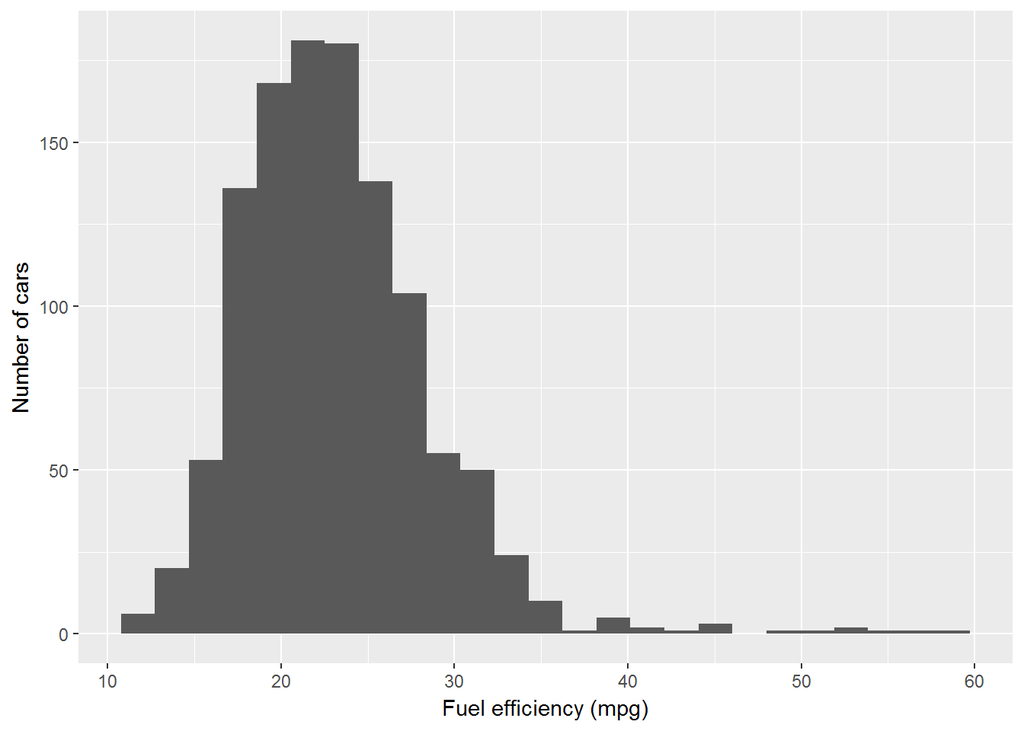

```r
# Plot the histogram
ggplot(cars2018, aes(x = MPG)) +
    geom_histogram(bins = 25) +
    labs(y = "Number of cars",
         x = "Fuel efficiency (mpg)")
```

```r
# Deselect the 2 columns to create cars_vars
cars_vars <- cars2018 %>%
    select(-Model, -`Model Index`)

# Fit a linear model
fit_all <- lm(MPG ~ ., data = cars_vars)

# Print the summary of the model
summary(fit_all)
```

```
##
## Call:
## lm(formula = MPG ~ ., data = cars_vars)
##
## Residuals:
##     Min      1Q  Median      3Q     Max
## -8.5261 -1.6473 -0.1096  1.3572 26.5045
##
## Coefficients:
##                                                 Estimate Std. Error
## (Intercept)                                    44.539519   1.176283
## Displacement                                   -3.786147   0.264845
## Cylinders                                       0.520284   0.161802
## Gears                                           0.157674   0.069984
## TransmissionCVT                                 4.877637   0.404051
## TransmissionManual                             -1.074608   0.366075
## AspirationTurbocharged/Supercharged            -2.190248   0.267559
## `Lockup Torque Converter`Y                     -2.624494   0.381252
## Drive2-Wheel Drive, Rear                       -2.676716   0.291044
## Drive4-Wheel Drive                             -3.397532   0.335147
## DriveAll Wheel Drive                           -2.941084   0.257174
## `Max Ethanol`                                  -0.007377   0.005898
## `Recommended Fuel`Premium Unleaded Required    -0.403935   0.262413
## `Recommended Fuel`Regular Unleaded Recommended -0.996343   0.272495
## `Intake Valves Per Cyl`                        -1.446107   1.620575
## `Exhaust Valves Per Cyl`                       -2.469747   1.547748
## `Fuel injection`Multipoint/sequential ignition -0.658428   0.243819
##                                                t value Pr(>|t|)
## (Intercept)                                     37.865  < 2e-16 ***
## Displacement                                   -14.296  < 2e-16 ***
## Cylinders                                        3.216 0.001339 **
## Gears                                            2.253 0.024450 *
## TransmissionCVT                                 12.072  < 2e-16 ***
## TransmissionManual                              -2.935 0.003398 **
## AspirationTurbocharged/Supercharged             -8.186 7.24e-16 ***
## `Lockup Torque Converter`Y                      -6.884 9.65e-12 ***
## Drive2-Wheel Drive, Rear                        -9.197  < 2e-16 ***
## Drive4-Wheel Drive                             -10.137  < 2e-16 ***
## DriveAll Wheel Drive                           -11.436  < 2e-16 ***
## `Max Ethanol`                                   -1.251 0.211265
## `Recommended Fuel`Premium Unleaded Required     -1.539 0.124010
## `Recommended Fuel`Regular Unleaded Recommended  -3.656 0.000268 ***
## `Intake Valves Per Cyl`                         -0.892 0.372400
## `Exhaust Valves Per Cyl`                        -1.596 0.110835
## `Fuel injection`Multipoint/sequential ignition  -2.700 0.007028 **
## ---
## Signif. codes:  0 '***' 0.001 '**' 0.01 '*' 0.05 '.' 0.1 ' ' 1
##
## Residual standard error: 2.916 on 1127 degrees of freedom
## Multiple R-squared:  0.7314, Adjusted R-squared:  0.7276
## F-statistic: 191.8 on 16 and 1127 DF,  p-value: < 2.2e-16
```

```r
# Load caret
library(caret)
# Split the data into training and test sets
set.seed(1234)
in_train <- createDataPartition(cars_vars$Transmission, p = 0.8, list = FALSE)
training <- cars_vars[in_train, ]
testing <- cars_vars[-in_train, ]

# Train a linear regression model
fit_lm <- train(log(MPG) ~ ., method = "lm", data = training,
                trControl = trainControl(method = "none"))

# Print the model object
fit_lm
```

```
## Linear Regression
##
## 916 samples
##  12 predictor
##
## No pre-processing
## Resampling: None
```

```r
# Train a random forest model
fit_rf <- train(log(MPG) ~ ., method = "rf", data = training,
                trControl = trainControl(method = "none"))

# Print the model object
fit_rf
```

```
## Random Forest
##
## 916 samples
##  12 predictor
##
## No pre-processing
## Resampling: None
```

```r
# Create the new columns
results <- training %>%
    mutate(`Linear regression` = predict(fit_lm, training),
           `Random forest` = predict(fit_rf, training))

# Evaluate the performance
yardstick::metrics(results, truth = MPG, estimate = `Linear regression`)
```

```
## # A tibble: 1 x 2
##    rmse   rsq
##   <dbl> <dbl>
## 1  20.9 0.702
```

```r
yardstick::metrics(results, truth = MPG, estimate = `Random forest`)
```

```
## # A tibble: 1 x 2
##    rmse   rsq
##   <dbl> <dbl>
## 1  20.9 0.845
```

```r
# Create the new columns
results <- testing %>%
    mutate(`Linear regression` = predict(fit_lm, testing),
           `Random forest` = predict(fit_rf, testing))

# Evaluate the performance
yardstick::metrics(results, truth = MPG, estimate = `Linear regression`)
```

```
## # A tibble: 1 x 2
##    rmse   rsq
##   <dbl> <dbl>
## 1  20.5 0.799
```

```r
yardstick::metrics(results, truth = MPG, estimate = `Random forest`)
```

```
## # A tibble: 1 x 2
##    rmse   rsq
##   <dbl> <dbl>
## 1  20.5 0.880
```

```r
# Fit the models with bootstrap resampling
cars_lm_bt <- train(log(MPG) ~ ., method = "lm", data = training,
                   trControl = trainControl(method = "boot"))
cars_rf_bt <- train(log(MPG) ~ ., method = "rf", data = training,
                   trControl = trainControl(method = "boot"))

# Quick look at the models
cars_lm_bt
```

```
## Linear Regression
##
## 916 samples
##  12 predictor
##
## No pre-processing
## Resampling: Bootstrapped (25 reps)
## Summary of sample sizes: 916, 916, 916, 916, 916, 916, ...
## Resampling results:
##
##   RMSE       Rsquared   MAE
##   0.1036278  0.7890514  0.07656104
##
## Tuning parameter 'intercept' was held constant at a value of TRUE
```

```r
cars_rf_bt
```

```
## Random Forest
##
## 916 samples
##  12 predictor
##
## No pre-processing
## Resampling: Bootstrapped (25 reps)
## Summary of sample sizes: 916, 916, 916, 916, 916, 916, ...
## Resampling results across tuning parameters:
##
##   mtry  RMSE        Rsquared   MAE
##    2    0.10015480  0.8205322  0.07299305
##    9    0.08758544  0.8466598  0.06129895
##   16    0.09100659  0.8360034  0.06313542
##
## RMSE was used to select the optimal model using the smallest value.
## The final value used for the model was mtry = 9.
```

```r
results <- testing %>%
    mutate(`Linear regression` = predict(cars_lm_bt, testing),
           `Random forest` = predict(cars_rf_bt, testing))

yardstick::metrics(results, truth = MPG, estimate = `Linear regression`)
```

```
## # A tibble: 1 x 2
##    rmse   rsq
##   <dbl> <dbl>
## 1  20.5 0.799
```

```r
yardstick::metrics(results, truth = MPG, estimate = `Random forest`)
```

```
## # A tibble: 1 x 2
##    rmse   rsq
##   <dbl> <dbl>
## 1  20.5 0.903
```

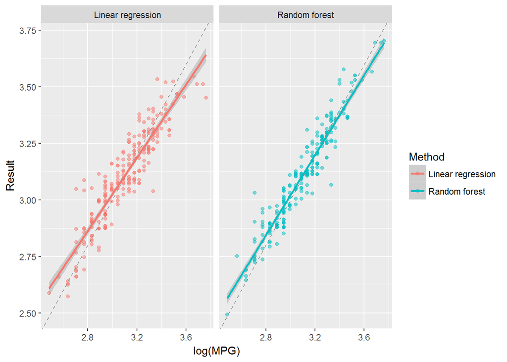

```r
results %>%
    gather(Method, Result, `Linear regression`:`Random forest`) %>%
    ggplot(aes(log(MPG), Result, color = Method)) +
    geom_point(size = 1.5, alpha = 0.5) +
    facet_wrap(~Method) +
    geom_abline(lty = 2, color = "gray50") +
    geom_smooth(method = "lm")
```

Chapter 2 - Stack Overflow Developer Data

Essential copying and pasting from Stack Overflow (largest and most trusted developer community):

- Annual survey of developer perspectives on Stack Overflow - can be used for predictive modeling
- Data is made available publicly at insights.stackoverflow.com/survey
- Key question is “what makes a developer more likely to work remotely” (size of company, geography of employee, etc.)
  - Data are calss imbalanced, with many more Non-Remote employees than Remote employees
  - Best first step is the simplest model - logit, without any tricks
  - simple_glm <- stackoverflow %>% select(-Respondent) %>% glm(Remote ~ ., family = “binomial”, + data = .) # Remote ~ . Means “all variables” while data=. Means from the piped dataset

Dealing with imbalanced data:

- Class imbalance is a common problem that can negatively impact model performance
  - This dataset has 10x the number of non-remote, which can influence models to just start predicting non-remote in all cases
- One approach to class imbalance is upsampling, basically running resampling with replacement on the small class until it is the same size as the large class
  - Simple to implement, but with the risk of over-fitting
  - up_train <- upSample(x = select(training, -Remote), y = training$Remote, yname = “Remote”) %>% as_tibble()
  - stack_glm <- train(Remote ~ ., method = “glm”, family = “binomial”, data = training, trControl = trainControl(method = “boot”, sampling = “up”))

Predicting remote status:

- Classification models can include logistic regression and random forests
  - stack_glm <- train(Remote ~ ., method = “glm”, family = “binomial”, data = training, trControl = trainControl(method = “boot”, sampling = “up”))
  - stack_rf <- train(Remote ~ ., method = “rf”, data = training, trControl = trainControl(method = “boot”, sampling = “up”))
- Classification models can be evaluated using the confusion matrix
  - confusionMatrix(predict(stack_glm, testing), testing$Remote)
  - yardstick::accuracy(testing_results, truth = Remote, estimate = `Logistic regression`)
  - yardstick::ppv(testing_results, truth = Remote, estimate = `Logistic regression`)
  - yardstick::npv(testing_results, truth = Remote, estimate = `Logistic regression`)

Example code includes:

```r
stackoverflow <- readr::read_csv("./RInputFiles/stackoverflow.csv")
stackoverflow$Remote <- factor(stackoverflow$Remote, levels=c("Not remote", "Remote"))
str(stackoverflow, give.attr = FALSE)
```

```
## Classes 'tbl_df', 'tbl' and 'data.frame':    6991 obs. of  22 variables:
##  $ Respondent                          : int  3 15 18 19 26 55 62 71 73 77 ...
##  $ Country                             : chr  "United Kingdom" "United Kingdom" "United States" "United States" ...
##  $ Salary                              : num  113750 100000 130000 82500 175000 ...
##  $ YearsCodedJob                       : int  20 20 20 3 16 4 1 1 20 20 ...
##  $ OpenSource                          : logi  TRUE FALSE TRUE FALSE FALSE FALSE ...
##  $ Hobby                               : logi  TRUE TRUE TRUE TRUE TRUE FALSE ...
##  $ CompanySizeNumber                   : num  10000 5000 1000 10000 10000 1000 5000 20 100 1000 ...
##  $ Remote                              : Factor w/ 2 levels "Not remote","Remote": 1 2 2 1 1 1 1 1 2 2 ...
##  $ CareerSatisfaction                  : int  8 8 9 5 7 9 5 8 8 10 ...
##  $ Data scientist                      : logi  FALSE FALSE FALSE FALSE FALSE FALSE ...
##  $ Database administrator              : logi  FALSE FALSE FALSE FALSE FALSE FALSE ...
##  $ Desktop applications developer      : logi  FALSE FALSE FALSE FALSE FALSE FALSE ...
##  $ Developer with stats/math background: logi  FALSE FALSE FALSE FALSE FALSE FALSE ...
##  $ DevOps                              : logi  FALSE FALSE TRUE FALSE FALSE FALSE ...
##  $ Embedded developer                  : logi  FALSE TRUE TRUE FALSE FALSE FALSE ...
##  $ Graphic designer                    : logi  FALSE FALSE FALSE FALSE FALSE FALSE ...
##  $ Graphics programming                : logi  FALSE FALSE FALSE FALSE FALSE FALSE ...
##  $ Machine learning specialist         : logi  FALSE FALSE FALSE FALSE FALSE FALSE ...
##  $ Mobile developer                    : logi  FALSE FALSE FALSE FALSE FALSE FALSE ...
##  $ Quality assurance engineer          : logi  FALSE FALSE TRUE FALSE FALSE FALSE ...
##  $ Systems administrator               : logi  FALSE FALSE FALSE FALSE FALSE FALSE ...
##  $ Web developer                       : logi  FALSE FALSE TRUE TRUE TRUE TRUE ...
```

```r
# Print stackoverflow
stackoverflow
```

```
## # A tibble: 6,991 x 22
##    Respondent Country        Salary YearsCodedJob OpenSource Hobby
##         <int> <chr>           <dbl>         <int> <lgl>      <lgl>
##  1          3 United Kingdom 113750            20 T          T
##  2         15 United Kingdom 100000            20 F          T
##  3         18 United States  130000            20 T          T
##  4         19 United States   82500             3 F          T
##  5         26 United States  175000            16 F          T
##  6         55 Germany         64516             4 F          F
##  7         62 India            6636             1 F          T
##  8         71 United States   65000             1 F          T
##  9         73 United States  120000            20 T          T
## 10         77 United States   96283            20 T          T
## # ... with 6,981 more rows, and 16 more variables:
## #   CompanySizeNumber <dbl>, Remote <fct>, CareerSatisfaction <int>, `Data
## #   scientist` <lgl>, `Database administrator` <lgl>, `Desktop
## #   applications developer` <lgl>, `Developer with stats/math
## #   background` <lgl>, DevOps <lgl>, `Embedded developer` <lgl>, `Graphic
## #   designer` <lgl>, `Graphics programming` <lgl>, `Machine learning
## #   specialist` <lgl>, `Mobile developer` <lgl>, `Quality assurance
## #   engineer` <lgl>, `Systems administrator` <lgl>, `Web developer` <lgl>
```

```r
# First count for Remote
stackoverflow %>%
    count(Remote, sort = TRUE)
```

```
## # A tibble: 2 x 2
##   Remote         n
##   <fct>      <int>
## 1 Not remote  6273
## 2 Remote       718
```

```r
# then count for Country
stackoverflow %>%
    count(Country, sort = TRUE)
```

```
## # A tibble: 5 x 2
##   Country            n
##   <chr>          <int>
## 1 United States   3486
## 2 United Kingdom  1270
## 3 Germany          950
## 4 India            666
## 5 Canada           619
```

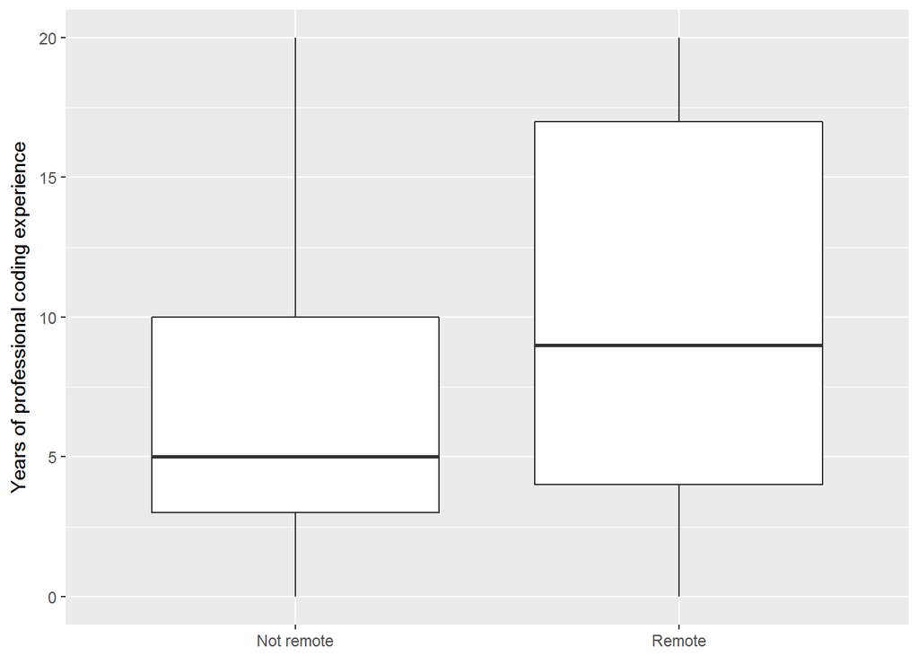

```r
ggplot(stackoverflow, aes(x=Remote, y=YearsCodedJob)) +
    geom_boxplot() +
    labs(x = NULL,
         y = "Years of professional coding experience")
```

```r
# Build a simple logistic regression model
simple_glm <- stackoverflow %>%
        select(-Respondent) %>%
        glm(Remote ~ .,
            family = "binomial",
            data = .)

# Print the summary of the model
summary(simple_glm)
```

```
##
## Call:
## glm(formula = Remote ~ ., family = "binomial", data = .)
##
## Deviance Residuals:
##     Min       1Q   Median       3Q      Max
## -1.1942  -0.4971  -0.3824  -0.2867   2.9118
##
## Coefficients:
##                                              Estimate Std. Error z value
## (Intercept)                                -4.156e+00  2.929e-01 -14.187
## CountryGermany                             -2.034e-01  2.196e-01  -0.927
## CountryIndia                                9.574e-01  2.220e-01   4.312
## CountryUnited Kingdom                       5.599e-02  1.974e-01   0.284
## CountryUnited States                        5.990e-01  1.799e-01   3.330
## Salary                                      4.076e-06  1.589e-06   2.565
## YearsCodedJob                               7.133e-02  7.556e-03   9.440
## OpenSourceTRUE                              4.207e-01  8.555e-02   4.917
## HobbyTRUE                                   8.330e-03  9.827e-02   0.085
## CompanySizeNumber                          -6.104e-05  1.223e-05  -4.990
## CareerSatisfaction                          6.748e-02  2.664e-02   2.533
## `Data scientist`TRUE                       -1.186e-01  1.838e-01  -0.645
## `Database administrator`TRUE                2.763e-01  1.267e-01   2.181
## `Desktop applications developer`TRUE       -2.903e-01  9.842e-02  -2.950
## `Developer with stats/math background`TRUE  2.840e-02  1.359e-01   0.209
## DevOpsTRUE                                 -1.532e-01  1.292e-01  -1.185
## `Embedded developer`TRUE                   -2.777e-01  1.653e-01  -1.680
## `Graphic designer`TRUE                     -1.904e-01  2.725e-01  -0.699
## `Graphics programming`TRUE                  1.078e-01  2.312e-01   0.466
## `Machine learning specialist`TRUE          -2.289e-01  2.769e-01  -0.827
## `Mobile developer`TRUE                      2.170e-01  1.019e-01   2.130
## `Quality assurance engineer`TRUE           -2.826e-01  2.437e-01  -1.160
## `Systems administrator`TRUE                 1.462e-01  1.421e-01   1.029
## `Web developer`TRUE                         1.158e-01  9.993e-02   1.159
##                                            Pr(>|z|)
## (Intercept)                                 < 2e-16 ***
## CountryGermany                             0.354161
## CountryIndia                               1.62e-05 ***
## CountryUnited Kingdom                      0.776710
## CountryUnited States                       0.000868 ***
```

[output cut: 14 more lines]

```
## `Machine learning specialist`TRUE          0.408484
## `Mobile developer`TRUE                     0.033194 *
## `Quality assurance engineer`TRUE           0.246098
## `Systems administrator`TRUE                0.303507
## `Web developer`TRUE                        0.246655
## ---
## Signif. codes:  0 '***' 0.001 '**' 0.01 '*' 0.05 '.' 0.1 ' ' 1
##
## (Dispersion parameter for binomial family taken to be 1)
##
##     Null deviance: 4627.8  on 6990  degrees of freedom
## Residual deviance: 4268.8  on 6967  degrees of freedom
## AIC: 4316.8
##
## Number of Fisher Scoring iterations: 5
```

```r
stack_select <- stackoverflow %>%
    select(-Respondent)

# Split the data into training and testing sets
set.seed(1234)
in_train <- caret::createDataPartition(stack_select$Remote, p=0.8, list = FALSE)
training <- stack_select[in_train,]
testing <- stack_select[-in_train,]


up_train <- caret::upSample(x = select(training, -Remote), y = training$Remote, yname = "Remote") %>%
    as_tibble()

up_train %>%
    count(Remote)
```

```
## # A tibble: 2 x 2
##   Remote         n
##   <fct>      <int>
## 1 Not remote  5019
## 2 Remote      5019
```

```r
# Sub-sample to 5% of original
inUse <- sample(1:nrow(training), round(0.05*nrow(training)), replace=FALSE)
useTrain <- training[sort(inUse), ]

# Build a logistic regression model
stack_glm <- caret::train(Remote ~ ., method="glm", family="binomial", data = training,
                          trControl = trainControl(method = "boot", sampling = "up")
                          )

# Print the model object
stack_glm
```

```
## Generalized Linear Model
##
## 5594 samples
##   20 predictor
##    2 classes: 'Not remote', 'Remote'
##
## No pre-processing
## Resampling: Bootstrapped (25 reps)
## Summary of sample sizes: 5594, 5594, 5594, 5594, 5594, 5594, ...
## Addtional sampling using up-sampling
##
## Resampling results:
##
##   Accuracy   Kappa
##   0.6568743  0.1279825
```

```r
# Build a random forest model
stack_rf <- caret::train(Remote ~ ., method="rf", data = useTrain,
                         trControl = trainControl(method = "boot", sampling="up")
                         )

# Print the model object
stack_rf
```

```
## Random Forest
##
## 280 samples
##  20 predictor
##   2 classes: 'Not remote', 'Remote'
##
## No pre-processing
## Resampling: Bootstrapped (25 reps)
## Summary of sample sizes: 280, 280, 280, 280, 280, 280, ...
## Addtional sampling using up-sampling
##
## Resampling results across tuning parameters:
##
##   mtry  Accuracy   Kappa
##    2    0.8626254   0.110738058
##   12    0.9038825  -0.002127159
##   23    0.8887612   0.035777206
##
## Accuracy was used to select the optimal model using the largest value.
## The final value used for the model was mtry = 12.
```

```r
# Confusion matrix for logistic regression model
caret::confusionMatrix(predict(stack_glm, testing), testing$Remote)
```

```
## Confusion Matrix and Statistics
##
##             Reference
## Prediction   Not remote Remote
##   Not remote        837     53
##   Remote            417     90
##
##                Accuracy : 0.6636
##                  95% CI : (0.6381, 0.6883)
##     No Information Rate : 0.8976
##     P-Value [Acc > NIR] : 1
##
##                   Kappa : 0.1395
##  Mcnemar's Test P-Value : <2e-16
##
##             Sensitivity : 0.6675
##             Specificity : 0.6294
##          Pos Pred Value : 0.9404
##          Neg Pred Value : 0.1775
##              Prevalence : 0.8976
##          Detection Rate : 0.5991
##    Detection Prevalence : 0.6371
##       Balanced Accuracy : 0.6484
##
##        'Positive' Class : Not remote
##
```

```r
# Confusion matrix for random forest model
caret::confusionMatrix(predict(stack_rf, testing), testing$Remote)
```

```
## Confusion Matrix and Statistics
##
##             Reference
## Prediction   Not remote Remote
##   Not remote       1207    125
##   Remote             47     18
##
##                Accuracy : 0.8769
##                  95% CI : (0.8585, 0.8937)
##     No Information Rate : 0.8976
##     P-Value [Acc > NIR] : 0.9945
##
##                   Kappa : 0.1166
##  Mcnemar's Test P-Value : 4.327e-09
##
##             Sensitivity : 0.9625
##             Specificity : 0.1259
##          Pos Pred Value : 0.9062
##          Neg Pred Value : 0.2769
##              Prevalence : 0.8976
##          Detection Rate : 0.8640
##    Detection Prevalence : 0.9535
##       Balanced Accuracy : 0.5442
##
##        'Positive' Class : Not remote
##
```

```r
# Predict values
testing_results <- testing %>%
    mutate(`Logistic regression` = predict(stack_glm, testing), `Random forest` = predict(stack_rf, testing))

## Calculate accuracy
yardstick::accuracy(testing_results, truth = Remote, estimate = `Logistic regression`)
```

```
## [1] 0.6635648
```

```r
yardstick::accuracy(testing_results, truth = Remote, estimate = `Random forest`)
```

```
## [1] 0.876879
```

```r
## Calculate positive predict value
yardstick::ppv(testing_results, truth = Remote, estimate = `Logistic regression`)
```

```
## [1] 0.9404494
```

```r
yardstick::ppv(testing_results, truth = Remote, estimate = `Random forest`)
```

```
## [1] 0.9061562
```

Chapter 3 - Voting

Predicting voter turnout from survey data:

- Survey data available from https://www.voterstudygroup.org/publications/2016-elections/data
  - Opinions about political and economic topics
  - Includes whether the voter turned out (voted), based on self-reporting, in the 2016 election
  - Data are coded as integers, requiring a data dictionary to map the questions and responses to what they mean

Vote 2016:

- Exploratory data analysis will help with learning about the underlying dataset
  - There are differences on many of the individual dimensions between voters and non-voters
  - A good first step can be to start with the very simplest model, Dependent ~ .

Cross-validation is the process of sub-dividing the data into folds, with each fold used once as the validation set:

- Allows for more accurate estimates of model performance on out-of-sample error
- Each process of CV will work through the data k times (assuming there are k folds)
  - Repeated CV is the process of running CV multiple times (this is particularly well suited to parallel processing)

Comparing model performance:

- Random forest models tend to be more powerful and capable of classifying the training data (and thus subject to risk of overfits and associated poor quality of test set predictions)

Example code includes:

```r
voters <- readr::read_csv("./RInputFiles/voters.csv")
voters$turnout16_2016 <- factor(voters$turnout16_2016, levels=c("Did not vote", "Voted"))
str(voters, give.attr = FALSE)
```

```
## Classes 'tbl_df', 'tbl' and 'data.frame':    6692 obs. of  43 variables:
##  $ case_identifier     : int  779 2108 2597 4148 4460 5225 5903 6059 8048 13112 ...
##  $ turnout16_2016      : Factor w/ 2 levels "Did not vote",..: 2 2 2 2 2 2 2 2 2 2 ...
##  $ RIGGED_SYSTEM_1_2016: int  3 2 2 1 3 3 3 2 4 2 ...
##  $ RIGGED_SYSTEM_2_2016: int  4 1 4 4 1 3 4 3 4 3 ...
##  $ RIGGED_SYSTEM_3_2016: int  1 3 1 1 3 2 1 3 1 1 ...
##  $ RIGGED_SYSTEM_4_2016: int  4 1 4 4 1 2 1 2 3 2 ...
##  $ RIGGED_SYSTEM_5_2016: int  3 3 1 2 3 2 2 1 3 2 ...
##  $ RIGGED_SYSTEM_6_2016: int  2 2 1 1 2 3 1 2 1 2 ...
##  $ track_2016          : int  2 2 1 1 2 2 1 2 2 2 ...
##  $ persfinretro_2016   : int  2 3 3 1 2 2 2 3 2 1 ...
##  $ econtrend_2016      : int  1 3 3 1 2 2 1 3 1 1 ...
##  $ Americatrend_2016   : int  1 1 1 3 3 1 2 3 2 1 ...
##  $ futuretrend_2016    : int  4 1 1 3 4 3 1 3 1 1 ...
##  $ wealth_2016         : int  2 1 2 2 1 2 2 1 2 2 ...
```

[output cut: 29 more lines]

```r
# Print voters
voters
```

```
## # A tibble: 6,692 x 43
##    case_identifier turnout16_2016 RIGGED_SYSTEM_1_2016 RIGGED_SYSTEM_2_20~
##              <int> <fct>                         <int>               <int>
##  1             779 Voted                             3                   4
##  2            2108 Voted                             2                   1
##  3            2597 Voted                             2                   4
##  4            4148 Voted                             1                   4
##  5            4460 Voted                             3                   1
##  6            5225 Voted                             3                   3
##  7            5903 Voted                             3                   4
##  8            6059 Voted                             2                   3
##  9            8048 Voted                             4                   4
## 10           13112 Voted                             2                   3
## # ... with 6,682 more rows, and 39 more variables:
## #   RIGGED_SYSTEM_3_2016 <int>, RIGGED_SYSTEM_4_2016 <int>,
## #   RIGGED_SYSTEM_5_2016 <int>, RIGGED_SYSTEM_6_2016 <int>,
## #   track_2016 <int>, persfinretro_2016 <int>, econtrend_2016 <int>,
## #   Americatrend_2016 <int>, futuretrend_2016 <int>, wealth_2016 <int>,
## #   values_culture_2016 <int>, US_respect_2016 <int>,
## #   trustgovt_2016 <int>, trust_people_2016 <int>,
## #   helpful_people_2016 <int>, fair_people_2016 <int>, imiss_a_2016 <int>,
## #   imiss_b_2016 <int>, imiss_c_2016 <int>, imiss_d_2016 <int>,
## #   imiss_e_2016 <int>, imiss_f_2016 <int>, imiss_g_2016 <int>,
## #   imiss_h_2016 <int>, imiss_i_2016 <int>, imiss_j_2016 <int>,
## #   imiss_k_2016 <int>, imiss_l_2016 <int>, imiss_m_2016 <int>,
## #   imiss_n_2016 <int>, imiss_o_2016 <int>, imiss_p_2016 <int>,
## #   imiss_q_2016 <int>, imiss_r_2016 <int>, imiss_s_2016 <int>,
## #   imiss_t_2016 <int>, imiss_u_2016 <int>, imiss_x_2016 <int>,
## #   imiss_y_2016 <int>
```

```r
# How many people voted?
voters %>%
    count(turnout16_2016)
```

```
## # A tibble: 2 x 2
##   turnout16_2016     n
##   <fct>          <int>
## 1 Did not vote     264
## 2 Voted           6428
```

```r
# How do the reponses on the survey vary with voting behavior?
voters %>%
    group_by(turnout16_2016) %>%
    summarize(`Elections don't matter` = mean(RIGGED_SYSTEM_1_2016 <= 2),
              `Economy is getting better` = mean(econtrend_2016 == 1),
              `Crime is very important` = mean(imiss_a_2016 == 2))
```

```
## # A tibble: 2 x 4
##   turnout16_2016 `Elections don't ~ `Economy is gettin~ `Crime is very im~
##   <fct>                       <dbl>               <dbl>              <dbl>
## 1 Did not vote                0.553               0.163              0.292
## 2 Voted                       0.341               0.289              0.342
```

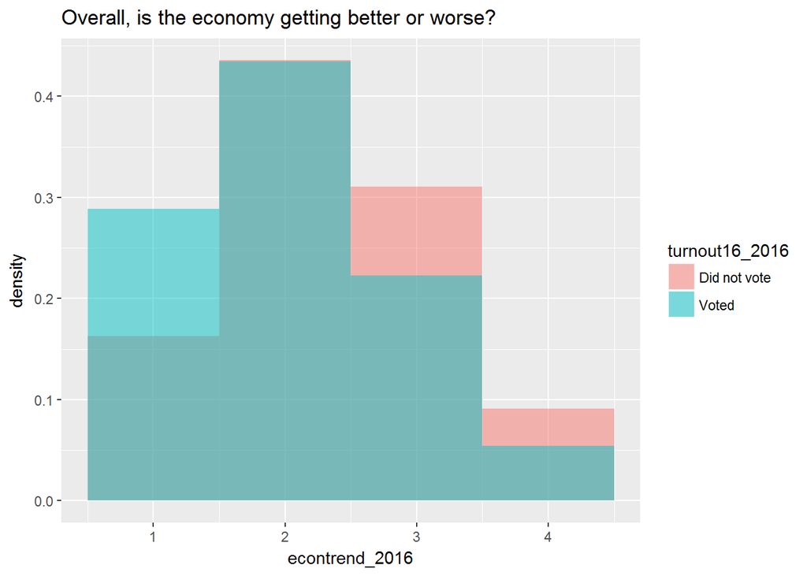

```r
## Visualize difference by voter turnout
voters %>%
    ggplot(aes(econtrend_2016, ..density.., fill = turnout16_2016)) +
    geom_histogram(alpha = 0.5, position = "identity", binwidth = 1) +
    labs(title = "Overall, is the economy getting better or worse?")
```

```r
# Remove the case_indetifier column
voters_select <- voters %>%
        select(-case_identifier)

# Build a simple logistic regression model
simple_glm <- glm(turnout16_2016 ~ .,  family = "binomial",
                  data = voters_select)

# Print the summary
summary(simple_glm)
```

```
##
## Call:
## glm(formula = turnout16_2016 ~ ., family = "binomial", data = voters_select)
##
## Deviance Residuals:
##     Min       1Q   Median       3Q      Max
## -3.2373   0.1651   0.2214   0.3004   1.7708
##
## Coefficients:
##                       Estimate Std. Error z value Pr(>|z|)
## (Intercept)           2.457036   0.732721   3.353 0.000799 ***
## RIGGED_SYSTEM_1_2016  0.236284   0.085081   2.777 0.005484 **
## RIGGED_SYSTEM_2_2016  0.064749   0.089208   0.726 0.467946
## RIGGED_SYSTEM_3_2016  0.049357   0.107352   0.460 0.645680
## RIGGED_SYSTEM_4_2016 -0.074694   0.087583  -0.853 0.393749
## RIGGED_SYSTEM_5_2016  0.190252   0.096454   1.972 0.048556 *
## RIGGED_SYSTEM_6_2016 -0.005881   0.101381  -0.058 0.953740
## track_2016            0.241075   0.121467   1.985 0.047178 *
## persfinretro_2016    -0.040229   0.106714  -0.377 0.706191
## econtrend_2016       -0.295370   0.087224  -3.386 0.000708 ***
## Americatrend_2016    -0.105213   0.080845  -1.301 0.193116
## futuretrend_2016      0.210568   0.071201   2.957 0.003103 **
## wealth_2016          -0.069405   0.026344  -2.635 0.008424 **
## values_culture_2016  -0.041402   0.038670  -1.071 0.284332
## US_respect_2016      -0.068200   0.043785  -1.558 0.119322
## trustgovt_2016        0.315354   0.166655   1.892 0.058456 .
## trust_people_2016     0.040423   0.041518   0.974 0.330236
## helpful_people_2016  -0.037513   0.035353  -1.061 0.288643
## fair_people_2016     -0.017081   0.030170  -0.566 0.571294
## imiss_a_2016          0.397121   0.138987   2.857 0.004273 **
## imiss_b_2016         -0.250803   0.155454  -1.613 0.106667
## imiss_c_2016          0.017536   0.090647   0.193 0.846606
## imiss_d_2016          0.043510   0.122118   0.356 0.721619
## imiss_e_2016         -0.095552   0.078603  -1.216 0.224126
## imiss_f_2016         -0.323280   0.105432  -3.066 0.002168 **
## imiss_g_2016         -0.332034   0.078673  -4.220 2.44e-05 ***
## imiss_h_2016         -0.157298   0.107111  -1.469 0.141954
## imiss_i_2016          0.088695   0.091467   0.970 0.332196
## imiss_j_2016          0.060271   0.138429   0.435 0.663280
## imiss_k_2016         -0.181030   0.082726  -2.188 0.028646 *
## imiss_l_2016          0.274689   0.106781   2.572 0.010098 *
## imiss_m_2016         -0.124269   0.147888  -0.840 0.400746
## imiss_n_2016         -0.441612   0.090040  -4.905 9.36e-07 ***
## imiss_o_2016          0.198635   0.143160   1.388 0.165286
## imiss_p_2016          0.102987   0.105669   0.975 0.329751
## imiss_q_2016          0.244567   0.119093   2.054 0.040017 *
## imiss_r_2016          0.198839   0.121969   1.630 0.103050
## imiss_s_2016         -0.067310   0.134465  -0.501 0.616666
## imiss_t_2016         -0.116757   0.068143  -1.713 0.086639 .
## imiss_u_2016          0.022902   0.097312   0.235 0.813939
## imiss_x_2016         -0.017789   0.097349  -0.183 0.855003
## imiss_y_2016          0.150205   0.094536   1.589 0.112092
## ---
## Signif. codes:  0 '***' 0.001 '**' 0.01 '*' 0.05 '.' 0.1 ' ' 1
##
## (Dispersion parameter for binomial family taken to be 1)
##
##     Null deviance: 2224.3  on 6691  degrees of freedom
## Residual deviance: 2004.4  on 6650  degrees of freedom
## AIC: 2088.4
##
## Number of Fisher Scoring iterations: 6
```

```r
# Split data into training and testing sets
set.seed(1234)
in_train <- caret::createDataPartition(voters_select$turnout16_2016, p = 0.8, list = FALSE)
training <- voters_select[in_train, ]
testing <- voters_select[-in_train, ]


# Perform logistic regression with upsampling and no resampling
vote_glm_1 <- caret::train(turnout16_2016 ~ ., method = "glm", family = "binomial", data = training,
                           trControl = trainControl(method = "none", sampling = "up")
                           )

# Print vote_glm
vote_glm_1
```

```
## Generalized Linear Model
##
## 5355 samples
##   41 predictor
##    2 classes: 'Did not vote', 'Voted'
##
## No pre-processing
## Resampling: None
## Addtional sampling using up-sampling
```

```r
useSmall <- sort(sample(1:nrow(training), round(0.1*nrow(training)), replace=FALSE))
trainSmall <- training[useSmall, ]

# Logistic regression
vote_glm <- caret::train(turnout16_2016 ~ ., method = "glm", family = "binomial", data = trainSmall,
                         trControl = trainControl(method = "repeatedcv", repeats = 2, sampling = "up")
                         )
```

[output not shown]

```r
# Print vote_glm
vote_glm
```

```
## Generalized Linear Model
##
## 536 samples
##  41 predictor
##   2 classes: 'Did not vote', 'Voted'
##
## No pre-processing
## Resampling: Cross-Validated (10 fold, repeated 2 times)
## Summary of sample sizes: 482, 482, 482, 483, 482, 483, ...
## Addtional sampling using up-sampling
##
## Resampling results:
##
##   Accuracy   Kappa
##   0.8713138  0.04298445
```

```r
# Random forest
vote_rf <- caret::train(turnout16_2016 ~ ., method = "rf", data = trainSmall,
                        trControl = trainControl(method="repeatedcv", repeats=2, sampling = "up")
                        )

# Print vote_rf
vote_rf
```

```
## Random Forest
##
## 536 samples
##  41 predictor
##   2 classes: 'Did not vote', 'Voted'
##
## No pre-processing
## Resampling: Cross-Validated (10 fold, repeated 2 times)
## Summary of sample sizes: 483, 482, 483, 482, 483, 483, ...
## Addtional sampling using up-sampling
##
## Resampling results across tuning parameters:
##
##   mtry  Accuracy   Kappa
##    2    0.9674179  -0.001265823
##   21    0.9627184  -0.006073829
##   41    0.9542628   0.019107234
##
## Accuracy was used to select the optimal model using the largest value.
## The final value used for the model was mtry = 2.
```

```r
# Confusion matrix for logistic regression model on training data
caret::confusionMatrix(predict(vote_glm, trainSmall), trainSmall$turnout16_2016)
```

```
## Confusion Matrix and Statistics
##
##               Reference
## Prediction     Did not vote Voted
##   Did not vote           17    48
##   Voted                   0   471
##
##                Accuracy : 0.9104
##                  95% CI : (0.883, 0.9332)
##     No Information Rate : 0.9683
##     P-Value [Acc > NIR] : 1
##
##                   Kappa : 0.3836
##  Mcnemar's Test P-Value : 1.17e-11
##
##             Sensitivity : 1.00000
##             Specificity : 0.90751
##          Pos Pred Value : 0.26154
##          Neg Pred Value : 1.00000
##              Prevalence : 0.03172
##          Detection Rate : 0.03172
##    Detection Prevalence : 0.12127
##       Balanced Accuracy : 0.95376
##
##        'Positive' Class : Did not vote
##
```

```r
# Confusion matrix for random forest model on training data
caret::confusionMatrix(predict(vote_rf, trainSmall), trainSmall$turnout16_2016)
```

```
## Confusion Matrix and Statistics
##
##               Reference
## Prediction     Did not vote Voted
##   Did not vote           17     0
##   Voted                   0   519
##
##                Accuracy : 1
##                  95% CI : (0.9931, 1)
##     No Information Rate : 0.9683
##     P-Value [Acc > NIR] : 3.143e-08
##
##                   Kappa : 1
##  Mcnemar's Test P-Value : NA
##
##             Sensitivity : 1.00000
##             Specificity : 1.00000
##          Pos Pred Value : 1.00000
##          Neg Pred Value : 1.00000
##              Prevalence : 0.03172
##          Detection Rate : 0.03172
##    Detection Prevalence : 0.03172
##       Balanced Accuracy : 1.00000
##
##        'Positive' Class : Did not vote
##
```

```r
# Confusion matrix for logistic regression model on testing data
caret::confusionMatrix(predict(vote_glm, testing), testing$turnout16_2016)
```

```
## Confusion Matrix and Statistics
##
##               Reference
## Prediction     Did not vote Voted
##   Did not vote           14   166
##   Voted                  38  1119
##
##                Accuracy : 0.8474
##                  95% CI : (0.827, 0.8663)
##     No Information Rate : 0.9611
##     P-Value [Acc > NIR] : 1
##
##                   Kappa : 0.0642
##  Mcnemar's Test P-Value : <2e-16
##
##             Sensitivity : 0.26923
##             Specificity : 0.87082
##          Pos Pred Value : 0.07778
##          Neg Pred Value : 0.96716
##              Prevalence : 0.03889
##          Detection Rate : 0.01047
##    Detection Prevalence : 0.13463
##       Balanced Accuracy : 0.57002
##
##        'Positive' Class : Did not vote
##
```

```r
# Confusion matrix for random forest model on testing data
caret::confusionMatrix(predict(vote_rf, testing), testing$turnout16_2016)
```

```
## Confusion Matrix and Statistics
##
##               Reference
## Prediction     Did not vote Voted
##   Did not vote            1     1
##   Voted                  51  1284
##
##                Accuracy : 0.9611
##                  95% CI : (0.9493, 0.9708)
##     No Information Rate : 0.9611
##     P-Value [Acc > NIR] : 0.5368
##
##                   Kappa : 0.0343
##  Mcnemar's Test P-Value : 1.083e-11
##
##             Sensitivity : 0.0192308
##             Specificity : 0.9992218
##          Pos Pred Value : 0.5000000
##          Neg Pred Value : 0.9617978
##              Prevalence : 0.0388930
##          Detection Rate : 0.0007479
##    Detection Prevalence : 0.0014959
##       Balanced Accuracy : 0.5092263
##
##        'Positive' Class : Did not vote
##
```

Chapter 4 - Nuns

Catholic sisters survey from 1967 - https://curate.nd.edu/show/0r967368551 with codebook at https://curate.nd.edu/downloads/0v838051f6x

- Responses from 130,000 sisters in ~400 congergations
- There was significant change occuring during this time period, both in society at large and within the community of nuns
- Age has been binned in groups of 10 years (has been recoded as a numeric at the top of the range, so 20 will mean 11-20 and 30 will mean 21-30 and the like)
- Historical dataset, centered in the context of nuns in 1967
- Good first step is to tidy the data, so that it is easier for exploratory data analysis
  - sisters67 %>% select(-sister) %>% gather(key, value, -age)

Exploratory data analysis with tidy data:

- Easy to see levels of agreement (overall) using dplyr::count()
- Agreement with specific questions by age
  - tidy_sisters %>% filter(key %in% paste0(“v”, 153:170)) %>% group_by(key, value) %>% summarise(age = mean(age)) %>% ggplot(aes(value, age, color = key)) + geom_line(alpha = 0.5, size = 1.5) + geom_point(size = 2) + facet_wrap(~key)
  - Can use the mix of responses to make estimates about the ages of the nuns
- Data will be split in to training, validation, and test sets
  - The validation set will be used for model selection

Predicting age with supervised learning:

- “rpart” - building a tree-based (CART) model
- “xgbLinear” - extreme gradient boosting
- “gbm” - gradient boosted ensembles
- Validation datasets are useful for assessing hyper-parameters and model choices, leaving the test dataset pure for a final out-of-sample error estimate

Wrap up:

- Train-Validation-Test to select the best models, tune the parameters, and estimate the out-of-sample error rates
- Dealing with class imbalances; improving performance with resamples (bootstraps, cross-validation, etc.)
- Hyper-parameter tuning can be valuable, but the time investment in other areas can often generate a greater return
- Gradient boosting and random forests tend to perform very well, but there is always value in trying out multiple models
  - Start with EDA and begin with a very simple model

Example code includes:

```r
sisters67 <- readr::read_csv("./RInputFiles/sisters.csv")
str(sisters67, give.attr = FALSE)
```

```
## Classes 'tbl_df', 'tbl' and 'data.frame':    19278 obs. of  67 variables:
##  $ age   : int  40 30 40 30 40 30 70 30 60 80 ...
##  $ sister: int  11545 16953 73323 75339 36303 95318 22474 114526 20707 91062 ...
##  $ v116  : int  5 4 2 4 4 2 4 4 4 5 ...
##  $ v117  : int  2 1 2 3 2 4 5 1 5 1 ...
##  $ v118  : int  2 4 5 3 3 5 5 4 5 2 ...
##  $ v119  : int  2 4 5 4 5 5 5 5 4 1 ...
##  $ v120  : int  4 1 3 3 1 1 5 1 5 2 ...
##  $ v121  : int  4 1 4 4 4 5 4 1 5 5 ...
##  $ v122  : int  4 1 2 2 4 1 1 2 2 1 ...
##  $ v123  : int  5 5 3 4 4 3 1 5 2 5 ...
##  $ v124  : int  1 1 5 2 3 1 5 3 5 4 ...
##  $ v125  : int  4 2 5 3 4 2 5 2 5 5 ...
##  $ v126  : int  2 1 1 3 1 1 5 1 5 2 ...
##  $ v127  : int  1 4 5 2 2 1 1 1 4 1 ...
```

[output cut: 53 more lines]

```r
# View sisters67
glimpse(sisters67)
```

```
## Observations: 19,278
## Variables: 67
## $ age    <int> 40, 30, 40, 30, 40, 30, 70, 30, 60, 80, 90, 40, 60, 80,...
## $ sister <int> 11545, 16953, 73323, 75339, 36303, 95318, 22474, 114526...
## $ v116   <int> 5, 4, 2, 4, 4, 2, 4, 4, 4, 5, 2, 5, 4, 4, 3, 4, 5, 3, 4...
## $ v117   <int> 2, 1, 2, 3, 2, 4, 5, 1, 5, 1, 3, 2, 5, 4, 1, 1, 1, 1, 2...
## $ v118   <int> 2, 4, 5, 3, 3, 5, 5, 4, 5, 2, 4, 4, 4, 5, 2, 4, 4, 4, 2...
## $ v119   <int> 2, 4, 5, 4, 5, 5, 5, 5, 4, 1, 4, 5, 3, 4, 5, 5, 5, 5, 4...
## $ v120   <int> 4, 1, 3, 3, 1, 1, 5, 1, 5, 2, 3, 1, 5, 4, 4, 1, 1, 1, 2...
## $ v121   <int> 4, 1, 4, 4, 4, 5, 4, 1, 5, 5, 4, 1, 3, 4, 3, 2, 5, 3, 3...
## $ v122   <int> 4, 1, 2, 2, 4, 1, 1, 2, 2, 1, 4, 5, 1, 2, 4, 2, 1, 4, 2...
## $ v123   <int> 5, 5, 3, 4, 4, 3, 1, 5, 2, 5, 3, 4, 3, 4, 5, 5, 4, 5, 4...
## $ v124   <int> 1, 1, 5, 2, 3, 1, 5, 3, 5, 4, 4, 1, 3, 2, 1, 1, 3, 2, 2...
## $ v125   <int> 4, 2, 5, 3, 4, 2, 5, 2, 5, 5, 5, 5, 5, 5, 1, 1, 5, 1, 2...
## $ v126   <int> 2, 1, 1, 3, 1, 1, 5, 1, 5, 2, 4, 1, 5, 1, 3, 1, 5, 1, 2...
```

[output cut: 54 more lines]

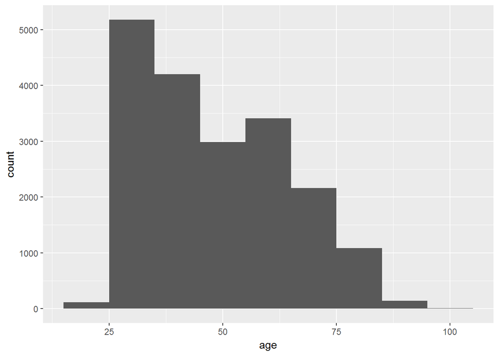

```r
# Plot the histogram
ggplot(sisters67, aes(x = age)) +
    geom_histogram(binwidth = 10)
```

```r
# Tidy the data set
tidy_sisters <- sisters67 %>%
    select(-sister) %>%
    gather(key, value, -age)

# Print the structure of tidy_sisters
glimpse(tidy_sisters)
```

```
## Observations: 1,253,070
## Variables: 3
## $ age   <int> 40, 30, 40, 30, 40, 30, 70, 30, 60, 80, 90, 40, 60, 80, ...
## $ key   <chr> "v116", "v116", "v116", "v116", "v116", "v116", "v116", ...
## $ value <int> 5, 4, 2, 4, 4, 2, 4, 4, 4, 5, 2, 5, 4, 4, 3, 4, 5, 3, 4,...
```

```r
# Overall agreement with all questions varied by age
tidy_sisters %>%
    group_by(age) %>%
    summarize(value = mean(value, na.rm = TRUE))
```

```
## # A tibble: 9 x 2
##     age value
##   <int> <dbl>
## 1    20  2.82
## 2    30  2.81
## 3    40  2.82
## 4    50  2.95
## 5    60  3.10
## 6    70  3.25
## 7    80  3.39
## 8    90  3.55
## 9   100  3.93
```

```r
# Number of respondents agreed or disagreed overall
tidy_sisters %>%
    count(value)
```

```
## # A tibble: 5 x 2
##   value      n
##   <int>  <int>
## 1     1 326386
## 2     2 211534
## 3     3 160961
## 4     4 277062
## 5     5 277127
```

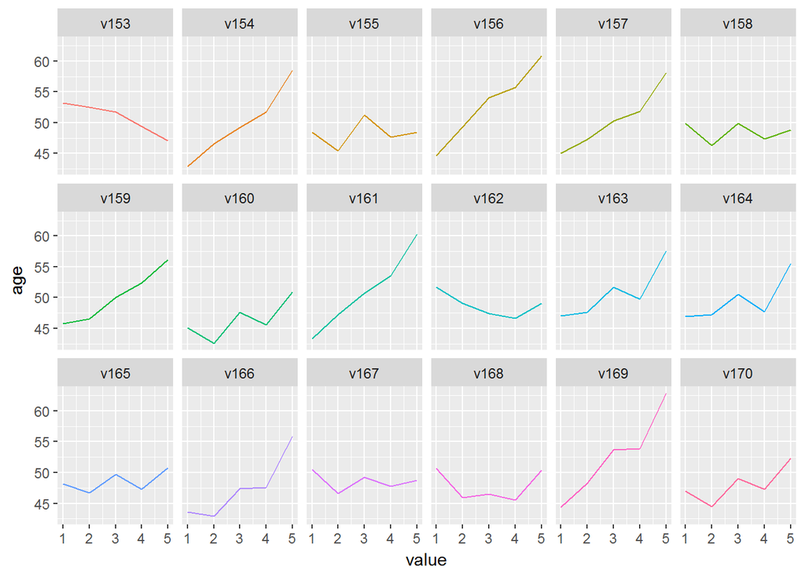

```r
# Visualize agreement with age
tidy_sisters %>%
    filter(key %in% paste0("v", 153:170)) %>%
    group_by(key, value) %>%
    summarize(age = mean(age, na.rm = TRUE)) %>%
    ggplot(aes(value, age, color = key)) +
    geom_line(show.legend = FALSE) +
    facet_wrap(~key, nrow = 3)
```

```r
# Remove the sister column
sisters_select <- sisters67 %>%
    select(-sister)

# Build a simple linear regression model
simple_lm <- lm(age ~ .,
                data = sisters_select)

# Print the summary of the model
summary(simple_lm)
```

```
##
## Call:
## lm(formula = age ~ ., data = sisters_select)
##
## Residuals:
##     Min      1Q  Median      3Q     Max
## -46.663  -9.586  -1.207   8.991  53.286
##
## Coefficients:
##             Estimate Std. Error t value Pr(>|t|)
## (Intercept) 27.59542    1.07173  25.748  < 2e-16 ***
## v116        -0.69014    0.07727  -8.931  < 2e-16 ***
## v117        -0.15914    0.08869  -1.794 0.072786 .
## v118        -0.74668    0.08473  -8.813  < 2e-16 ***
## v119        -0.35314    0.08321  -4.244 2.21e-05 ***
## v120        -0.13875    0.07513  -1.847 0.064813 .
## v121         0.04265    0.07794   0.547 0.584247
## v122         0.05237    0.08086   0.648 0.517208
## v123        -0.96372    0.09061 -10.636  < 2e-16 ***
## v124         0.44543    0.08681   5.131 2.91e-07 ***
## v125         0.50420    0.07425   6.791 1.15e-11 ***
## v126         0.44358    0.08579   5.170 2.36e-07 ***
## v127        -0.04781    0.07915  -0.604 0.545810
## v128         0.04459    0.07595   0.587 0.557162
## v129         0.03044    0.07881   0.386 0.699351
## v130         0.51028    0.08064   6.328 2.54e-10 ***
## v131        -0.54431    0.08417  -6.467 1.02e-10 ***
## v132        -0.02527    0.09337  -0.271 0.786703
## v133        -0.67041    0.07563  -8.864  < 2e-16 ***
## v134        -0.12144    0.09060  -1.340 0.180130
## v135         0.45773    0.10886   4.205 2.63e-05 ***
## v136        -0.08790    0.07438  -1.182 0.237293
## v137         0.74412    0.10230   7.274 3.63e-13 ***
## v138         0.31534    0.10601   2.974 0.002939 **
## v139         1.36585    0.10514  12.990  < 2e-16 ***
## v140        -0.73675    0.07371  -9.995  < 2e-16 ***
## v141         0.50515    0.09355   5.400 6.75e-08 ***
## v142        -0.22168    0.08357  -2.653 0.007992 **
## v143         0.08320    0.08375   0.993 0.320536
## v144         1.09413    0.10870  10.066  < 2e-16 ***
```

[output cut: 27 more lines]

```
## v172         0.07702    0.07176   1.073 0.283135
## v173         0.76461    0.06936  11.025  < 2e-16 ***
## v174         0.22074    0.07851   2.812 0.004934 **
## v175         0.18369    0.07930   2.316 0.020553 *
## v176         1.03334    0.08996  11.487  < 2e-16 ***
## v177        -0.07908    0.09643  -0.820 0.412153
## v178        -0.08005    0.08250  -0.970 0.331906
## v179         0.29778    0.09251   3.219 0.001289 **
## v180         0.11524    0.08566   1.345 0.178538
## ---
## Signif. codes:  0 '***' 0.001 '**' 0.01 '*' 0.05 '.' 0.1 ' ' 1
##
## Residual standard error: 13.13 on 19212 degrees of freedom
## Multiple R-squared:  0.3332, Adjusted R-squared:  0.3309
## F-statistic: 147.7 on 65 and 19212 DF,  p-value: < 2.2e-16
```

```r
# Split the data into training and validation/test sets
set.seed(1234)
in_train <- caret::createDataPartition(sisters_select$age, p = 0.6, list = FALSE)
training <- sisters_select[in_train, ]
validation_test <- sisters_select[-in_train, ]

# Split the validation and test sets
set.seed(1234)
in_test <- caret::createDataPartition(validation_test$age, p = 0.5, list = FALSE)
testing <- validation_test[in_test, ]
validation <- validation_test[-in_test, ]


# Fit a CART model
sisters_cart <- caret::train(age ~ ., method = "rpart", data = training)
# Print the CART model
sisters_cart
```

```
## CART
##
## 11569 samples
##    65 predictor
##
## No pre-processing
## Resampling: Bootstrapped (25 reps)
## Summary of sample sizes: 11569, 11569, 11569, 11569, 11569, 11569, ...
## Resampling results across tuning parameters:
##
##   cp          RMSE      Rsquared   MAE
##   0.02304336  14.61359  0.1724244  12.00686
##   0.04935303  14.89119  0.1403800  12.41303
##   0.11481230  15.54485  0.1046127  13.19914
##
## RMSE was used to select the optimal model using the smallest value.
## The final value used for the model was cp = 0.02304336.
```

```r
inSmall <- sample(1:nrow(training), 500, replace=FALSE)
smallSisters <- training[sort(inSmall), ]

sisters_xgb <- caret::train(age ~ ., method = "xgbTree", data = smallSisters)
sisters_gbm <- caret::train(age ~ ., method = "gbm", data = smallSisters, verbose=FALSE)

# Make predictions on the three models
modeling_results <- validation %>%
    mutate(CART = predict(sisters_cart, validation),
           XGB = predict(sisters_xgb, validation),
           GBM = predict(sisters_gbm, validation))

# View the predictions
modeling_results %>%
    select(CART, XGB, GBM)
```

```
## # A tibble: 3,854 x 3
##     CART   XGB   GBM
##    <dbl> <dbl> <dbl>
##  1  49.5  46.2  44.3
##  2  49.5  61.1  56.5
##  3  58.0  59.9  65.6
##  4  58.0  60.0  61.9
##  5  58.0  71.6  74.6
##  6  49.5  50.9  53.4
##  7  49.5  58.6  55.0
##  8  49.5  42.2  38.0
##  9  41.3  41.7  38.2
## 10  58.0  51.6  50.0
## # ... with 3,844 more rows
```

```r
# Compare performace
yardstick::metrics(modeling_results, truth = age, estimate = CART)
```

```
## # A tibble: 1 x 2
##    rmse   rsq
##   <dbl> <dbl>
## 1  14.6 0.163
```

```r
yardstick::metrics(modeling_results, truth = age, estimate = XGB)
```

```
## # A tibble: 1 x 2
##    rmse   rsq
##   <dbl> <dbl>
## 1  13.5 0.287
```

```r
yardstick::metrics(modeling_results, truth = age, estimate = GBM)
```

```
## # A tibble: 1 x 2
##    rmse   rsq
##   <dbl> <dbl>
## 1  13.6 0.286
```

```r
# Calculate RMSE
testing %>%
    mutate(prediction = predict(sisters_gbm, testing)) %>%
    yardstick::rmse(truth = age, estimate = prediction)
```

```
## [1] 13.87981
```

### *Business Process Analytics in R*

Chapter 1 - Introduction to Process Analysis